# Bike_sharing_FordGoBike_Exploratory_Analysis

### Dataset Overview :

```python
import pandas as pd
import numpy as np
import matplotlib.pyplot as plt
import seaborn as sb
import glob
import os
import  datetime
%matplotlib inline
```

```python
# Import the ford bike dataset for 2018 across months and combine them together
path = r'C:\Users\rdeshpande\Dropbox\Udacity\Project5- Data Visualization\Ford bike data\Input_data'


extension = 'csv'
os.chdir(path)
result = glob.glob('*.{}'.format(extension))
print(result)
```

```
['201801-fordgobike-tripdata.csv', '201802-fordgobike-tripdata.csv', '201803-fordgobike-tripdata.csv', '201804-fordgobike-tripdata.csv', '201805-fordgobike-tripdata.csv', '201806-fordgobike-tripdata.csv', '201807-fordgobike-tripdata.csv', '201808-fordgobike-tripdata.csv', '201809-fordgobike-tripdata…
```

```python
combined_csv = pd.concat([pd.read_csv(f) for f in result ])
```

```python
combined_csv
```

|  | duration_sec | start_time | end_time | start_station_id | start_station_name | start_station_latitude | start_station_longitude | end_station_id | end_station_name | end_station_latitude | end_station_longitude | bike_id | user_type | member_birth_year | member_gender | bike_share_for_all_trip |
| --- | --- | --- | --- | --- | --- | --- | --- | --- | --- | --- | --- | --- | --- | --- | --- | --- |
| 0 | 75284 | 2018-01-31 22:52:35.2390 | 2018-02-01 19:47:19.8240 | 120.0 | Mission Dolores Park | 37.761420 | -122.426435 | 285.0 | Webster St at O'Farrell St | 37.783521 | -122.431158 | 2765 | Subscriber | 1986.0 | Male | No |
| 1 | 85422 | 2018-01-31 16:13:34.3510 | 2018-02-01 15:57:17.3100 | 15.0 | San Francisco Ferry Building (Harry Bridges Pl... | 37.795392 | -122.394203 | 15.0 | San Francisco Ferry Building (Harry Bridges Pl... | 37.795392 | -122.394203 | 2815 | Customer | NaN | NaN | No |
| 2 | 71576 | 2018-01-31 14:23:55.8890 | 2018-02-01 10:16:52.1160 | 304.0 | Jackson St at 5th St | 37.348759 | -121.894798 | 296.0 | 5th St at Virginia St | 37.325998 | -121.877120 | 3039 | Customer | 1996.0 | Male | No |
| 3 | 61076 | 2018-01-31 14:53:23.5620 | 2018-02-01 07:51:20.5000 | 75.0 | Market St at Franklin St | 37.773793 | -122.421239 | 47.0 | 4th St at Harrison St | 37.780955 | -122.399749 | 321 | Customer | NaN | NaN | No |
| 4 | 39966 | 2018-01-31 19:52:24.6670 | 2018-02-01 06:58:31.0530 | 74.0 | Laguna St at Hayes St | 37.776435 | -122.426244 | 19.0 | Post St at Kearny St | 37.788975 | -122.403452 | 617 | Subscriber | 1991.0 | Male | No |
| 5 | 6477 | 2018-01-31 22:58:44.8670 | 2018-02-01 00:46:41.9080 | 236.0 | Market St at 8th St | 37.803686 | -122.282497 | 160.0 | West Oakland BART Station | 37.805318 | -122.294837 | 1306 | Customer | NaN | NaN | No |
| 6 | 453 | 2018-01-31 23:53:53.6320 | 2018-02-01 00:01:26.8050 | 110.0 | 17th & Folsom Street Park (17th St at Folsom St) | 37.763708 | -122.415204 | 134.0 | Valencia St at 24th St | 37.752428 | -122.420628 | 3571 | Subscriber | 1988.0 | Male | No |
| 7 | 180 | 2018-01-31 23:52:09.9030 | 2018-01-31 23:55:10.8070 | 81.0 | Berry St at 4th St | 37.775880 | -122.393170 | 93.0 | 4th St at Mission Bay Blvd S | 37.770407 | -122.391198 | 1403 | Subscriber | 1980.0 | Male | No |
| 8 | 996 | 2018-01-31 23:34:56.0040 | 2018-01-31 23:51:32.6740 | 134.0 | Valencia St at 24th St | 37.752428 | -122.420628 | 4.0 | Cyril Magnin St at Ellis St | 37.785881 | -122.408915 | 3675 | Subscriber | 1987.0 | Male | Yes |
| 9 | 825 | 2018-01-31 23:34:14.0270 | 2018-01-31 23:47:59.8090 | 305.0 | Ryland Park | 37.342725 | -121.895617 | 317.0 | San Salvador St at 9th St | 37.333955 | -121.877349 | 1453 | Subscriber | 1994.0 | Female | Yes |
| 10 | 1316 | 2018-01-31 23:24:00.4160 | 2018-01-31 23:45:56.8240 | 98.0 | Valencia St at 16th St | 37.765052 | -122.421866 | 4.0 | Cyril Magnin St at Ellis St | 37.785881 | -122.408915 | 1278 | Customer | NaN | NaN | No |
| 11 | 432 | 2018-01-31 23:34:26.4840 | 2018-01-31 23:41:39.2970 | 89.0 | Division St at Potrero Ave | 37.769218 | -122.407646 | 43.0 | San Francisco Public Library (Grove St at Hyde... | 37.778768 | -122.415929 | 2928 | Subscriber | 1993.0 | Male | No |
| 12 | 601 | 2018-01-31 23:29:46.8320 | 2018-01-31 23:39:48.0000 | 223.0 | 16th St Mission BART Station 2 | 37.764765 | -122.420091 | 86.0 | Market St at Dolores St | 37.769305 | -122.426826 | 3016 | Subscriber | 1957.0 | Male | No |
| 13 | 887 | 2018-01-31 23:24:16.3570 | 2018-01-31 23:39:04.1230 | 308.0 | San Pedro Square | 37.336802 | -121.894090 | 297.0 | Locust St at Grant St | 37.322980 | -121.887931 | 55 | Subscriber | 1976.0 | Female | Yes |
| 14 | 210 | 2018-01-31 23:33:03.0460 | 2018-01-31 23:36:33.7040 | 7.0 | Frank H Ogawa Plaza | 37.804562 | -122.271738 | 186.0 | Lakeside Dr at 14th St | 37.801319 | -122.262642 | 2602 | Subscriber | 1976.0 | Male | No |
| 15 | 188 | 2018-01-31 23:30:58.1360 | 2018-01-31 23:34:06.3910 | 98.0 | Valencia St at 16th St | 37.765052 | -122.421866 | 76.0 | McCoppin St at Valencia St | 37.771662 | -122.422423 | 2556 | Subscriber | 1964.0 | Female | No |
| 16 | 808 | 2018-01-31 23:19:58.6030 | 2018-01-31 23:33:27.5310 | 67.0 | San Francisco Caltrain Station 2 (Townsend St... | 37.776639 | -122.395526 | 98.0 | Valencia St at 16th St | 37.765052 | -122.421866 | 3041 | Subscriber | 1976.0 | Male | Yes |
| 17 | 378 | 2018-01-31 23:23:23.0680 | 2018-01-31 23:29:42.0440 | 80.0 | Townsend St at 5th St | 37.775306 | -122.397380 | 78.0 | Folsom St at 9th St | 37.773717 | -122.411647 | 546 | Subscriber | 1995.0 | Female | No |
| 18 | 350 | 2018-01-31 23:13:45.5290 | 2018-01-31 23:19:36.2650 | 247.0 | Fulton St at Bancroft Way | 37.867789 | -122.265896 | 274.0 | Oregon St at Adeline St | 37.857567 | -122.267558 | 431 | Subscriber | NaN | NaN | No |
| 19 | 686 | 2018-01-31 23:07:15.3130 | 2018-01-31 23:18:41.5580 | 312.0 | San Jose Diridon Station | 37.329732 | -121.901782 | 317.0 | San Salvador St at 9th St | 37.333955 | -121.877349 | 1886 | Subscriber | 1997.0 | Female | No |
| 20 | 450 | 2018-01-31 23:07:13.0630 | 2018-01-31 23:14:43.8140 | 241.0 | Ashby BART Station | 37.852477 | -122.270213 | 157.0 | 65th St at Hollis St | 37.846784 | -122.291376 | 3583 | Subscriber | 1994.0 | Male | No |
| 21 | 294 | 2018-01-31 23:08:12.0000 | 2018-01-31 23:13:06.6360 | 239.0 | Bancroft Way at Telegraph Ave | 37.868813 | -122.258764 | 244.0 | Shattuck Ave at Hearst Ave | 37.873792 | -122.268618 | 2144 | Subscriber | 1983.0 | Male | No |
| 22 | 150 | 2018-01-31 23:10:09.5860 | 2018-01-31 23:12:40.3330 | 182.0 | 19th Street BART Station | 37.809013 | -122.268247 | 183.0 | Telegraph Ave at 19th St | 37.808702 | -122.269927 | 3468 | Subscriber | 1945.0 | Male | Yes |
| 23 | 462 | 2018-01-31 23:03:48.9400 | 2018-01-31 23:11:31.0290 | 119.0 | 18th St at Noe St | 37.761047 | -122.432642 | 134.0 | Valencia St at 24th St | 37.752428 | -122.420628 | 1432 | Subscriber | 1971.0 | Male | Yes |
| 24 | 379 | 2018-01-31 23:04:27.7010 | 2018-01-31 23:10:46.9760 | 176.0 | MacArthur BART Station | 37.828410 | -122.266315 | 189.0 | Genoa St at 55th St | 37.839649 | -122.271756 | 997 | Subscriber | 1975.0 | Male | No |
| 25 | 880 | 2018-01-31 22:53:41.3020 | 2018-01-31 23:08:21.4430 | 123.0 | Folsom St at 19th St | 37.760594 | -122.414817 | 145.0 | 29th St at Church St | 37.743684 | -122.426806 | 3725 | Subscriber | 1986.0 | Male | No |
| 26 | 1210 | 2018-01-31 22:45:37.1250 | 2018-01-31 23:05:47.5760 | 285.0 | Webster St at O'Farrell St | 37.783521 | -122.431158 | 133.0 | Valencia St at 22nd St | 37.755213 | -122.420975 | 1059 | Subscriber | 1991.0 | Male | No |
| 27 | 259 | 2018-01-31 23:01:12.7920 | 2018-01-31 23:05:32.1570 | 239.0 | Bancroft Way at Telegraph Ave | 37.868813 | -122.258764 | 266.0 | Parker St at Fulton St | 37.862464 | -122.264791 | 1208 | Subscriber | 1994.0 | Male | No |
| 28 | 592 | 2018-01-31 22:53:27.7790 | 2018-01-31 23:03:20.2900 | 202.0 | Washington St at 8th St | 37.800754 | -122.274894 | 195.0 | Bay Pl at Vernon St | 37.812314 | -122.260779 | 1834 | Customer | 1978.0 | Male | No |
| 29 | 1059 | 2018-01-31 22:45:16.5700 | 2018-01-31 23:02:56.2850 | 141.0 | Valencia St at Cesar Chavez St | 37.747998 | -122.420219 | 79.0 | 7th St at Brannan St | 37.773492 | -122.403673 | 1248 | Subscriber | 1988.0 | Male | No |
| ... | ... | ... | ... | ... | ... | ... | ... | ... | ... | ... | ... | ... | ... | ... | ... | ... |
| 131333 | 310 | 2018-12-01 00:45:44.8680 | 2018-12-01 00:50:55.7970 | 252.0 | Channing Way at Shattuck Ave | 37.865847 | -122.267443 | 238.0 | MLK Jr Way at University Ave | 37.871719 | -122.273068 | 367 | Subscriber | 1991.0 | Male | No |
| 131334 | 1338 | 2018-12-01 00:27:24.8750 | 2018-12-01 00:49:43.3490 | 371.0 | Lombard St at Columbus Ave | 37.802746 | -122.413579 | 104.0 | 4th St at 16th St | 37.767045 | -122.390833 | 1985 | Subscriber | 1986.0 | Male | No |
| 131335 | 154 | 2018-12-01 00:44:24.8380 | 2018-12-01 00:46:59.3350 | 70.0 | Central Ave at Fell St | 37.773311 | -122.444293 | 52.0 | McAllister St at Baker St | 37.777416 | -122.441838 | 449 | Subscriber | 1994.0 | Male | No |
| 131336 | 862 | 2018-12-01 00:32:11.0630 | 2018-12-01 00:46:33.7900 | 4.0 | Cyril Magnin St at Ellis St | 37.785881 | -122.408915 | 86.0 | Market St at Dolores St | 37.769305 | -122.426826 | 4408 | Customer | 1975.0 | Male | No |
| 131337 | 1310 | 2018-12-01 00:23:53.3420 | 2018-12-01 00:45:43.5880 | 85.0 | Church St at Duboce Ave | 37.770083 | -122.429156 | 13.0 | Commercial St at Montgomery St | 37.794231 | -122.402923 | 1525 | Subscriber | 1994.0 | Male | Yes |
| 131338 | 230 | 2018-12-01 00:41:31.9550 | 2018-12-01 00:45:22.4160 | 312.0 | San Jose Diridon Station | 37.329732 | -121.901782 | 314.0 | Santa Clara St at Almaden Blvd | 37.333988 | -121.894902 | 1379 | Subscriber | 1957.0 | Male | No |
| 131339 | 2071 | 2018-12-01 00:09:55.5800 | 2018-12-01 00:44:26.6290 | 36.0 | Folsom St at 3rd St | 37.783830 | -122.398870 | 97.0 | 14th St at Mission St | 37.768265 | -122.420110 | 316 | Customer | 1991.0 | Male | No |
| 131340 | 1958 | 2018-12-01 00:11:35.0220 | 2018-12-01 00:44:13.6320 | 44.0 | Civic Center/UN Plaza BART Station (Market St ... | 37.781074 | -122.411738 | 5.0 | Powell St BART Station (Market St at 5th St) | 37.783899 | -122.408445 | 4395 | Subscriber | 1993.0 | Male | No |
| 131341 | 268 | 2018-12-01 00:37:23.1340 | 2018-12-01 00:41:51.9670 | 147.0 | 29th St at Tiffany Ave | 37.744067 | -122.421472 | 121.0 | Mission Playground | 37.759210 | -122.421339 | 4451 | Subscriber | 1989.0 | Male | No |
| 131342 | 1679 | 2018-12-01 00:13:35.1430 | 2018-12-01 00:41:34.8600 | 240.0 | Haste St at Telegraph Ave | 37.866043 | -122.258804 | 245.0 | Downtown Berkeley BART | 37.870139 | -122.268422 | 3701 | Customer | 1998.0 | Female | No |
| 131343 | 1658 | 2018-12-01 00:13:33.1240 | 2018-12-01 00:41:11.7630 | 240.0 | Haste St at Telegraph Ave | 37.866043 | -122.258804 | 245.0 | Downtown Berkeley BART | 37.870139 | -122.268422 | 3625 | Customer | 1998.0 | Female | No |
| 131344 | 293 | 2018-12-01 00:36:01.5250 | 2018-12-01 00:40:55.2850 | 95.0 | Sanchez St at 15th St | 37.766219 | -122.431060 | 72.0 | Page St at Scott St | 37.772406 | -122.435650 | 1043 | Subscriber | 1981.0 | Male | No |
| 131345 | 426 | 2018-12-01 00:32:13.1250 | 2018-12-01 00:39:19.8710 | 50.0 | 2nd St at Townsend St | 37.780526 | -122.390288 | 21.0 | Montgomery St BART Station (Market St at 2nd St) | 37.789625 | -122.400811 | 3154 | Subscriber | 1986.0 | Male | No |
| 131346 | 447 | 2018-12-01 00:31:36.1480 | 2018-12-01 00:39:03.3910 | 368.0 | Myrtle St at Polk St | 37.785434 | -122.419622 | 17.0 | Embarcadero BART Station (Beale St at Market St) | 37.792251 | -122.397086 | 1677 | Subscriber | 1980.0 | Other | Yes |
| 131347 | 1694 | 2018-12-01 00:09:17.1590 | 2018-12-01 00:37:31.2400 | 14.0 | Clay St at Battery St | 37.795001 | -122.399970 | 147.0 | 29th St at Tiffany Ave | 37.744067 | -122.421472 | 209 | Subscriber | 1993.0 | Male | No |
| 131348 | 269 | 2018-12-01 00:31:00.0910 | 2018-12-01 00:35:29.8710 | 98.0 | Valencia St at 16th St | 37.765052 | -122.421866 | 121.0 | Mission Playground | 37.759210 | -122.421339 | 3147 | Subscriber | 1993.0 | Male | No |
| 131349 | 685 | 2018-12-01 00:21:16.2400 | 2018-12-01 00:32:42.0000 | 109.0 | 17th St at Valencia St | 37.763316 | -122.421904 | 60.0 | 8th St at Ringold St | 37.774520 | -122.409449 | 3247 | Subscriber | 1987.0 | Female | No |
| 131350 | 681 | 2018-12-01 00:19:41.3830 | 2018-12-01 00:31:02.6050 | 15.0 | San Francisco Ferry Building (Harry Bridges Pl... | 37.795392 | -122.394203 | 323.0 | Broadway at Kearny | 37.798014 | -122.405950 | 3460 | Subscriber | 1959.0 | Male | No |
| 131351 | 1166 | 2018-12-01 00:11:04.8640 | 2018-12-01 00:30:31.3480 | 160.0 | West Oakland BART Station | 37.805318 | -122.294837 | 155.0 | Emeryville Public Market | 37.840521 | -122.293528 | 1579 | Subscriber | 1997.0 | Male | No |
| 131352 | 763 | 2018-12-01 00:17:34.4970 | 2018-12-01 00:30:18.1070 | 73.0 | Pierce St at Haight St | 37.771793 | -122.433708 | 121.0 | Mission Playground | 37.759210 | -122.421339 | 90 | Subscriber | 1991.0 | Female | No |
| 131353 | 760 | 2018-12-01 00:17:29.9600 | 2018-12-01 00:30:10.1780 | 73.0 | Pierce St at Haight St | 37.771793 | -122.433708 | 121.0 | Mission Playground | 37.759210 | -122.421339 | 2758 | Subscriber | 1991.0 | Male | No |
| 131354 | 538 | 2018-12-01 00:16:34.0850 | 2018-12-01 00:25:32.4550 | 5.0 | Powell St BART Station (Market St at 5th St) | 37.783899 | -122.408445 | 39.0 | Scott St at Golden Gate Ave | 37.778999 | -122.436861 | 4384 | Subscriber | 1991.0 | Male | No |
| 131355 | 671 | 2018-12-01 00:12:49.6400 | 2018-12-01 00:24:01.5120 | 34.0 | Father Alfred E Boeddeker Park | 37.783988 | -122.412408 | 92.0 | Mission Bay Kids Park | 37.772301 | -122.393028 | 4377 | Subscriber | 1972.0 | Male | Yes |
| 131356 | 498 | 2018-12-01 00:14:41.7250 | 2018-12-01 00:23:00.4080 | 7.0 | Frank H Ogawa Plaza | 37.804562 | -122.271738 | 214.0 | Market St at Brockhurst St | 37.823321 | -122.275732 | 2236 | Subscriber | 1992.0 | Male | No |
| 131357 | 1137 | 2018-12-01 00:01:49.6930 | 2018-12-01 00:20:47.5190 | 73.0 | Pierce St at Haight St | 37.771793 | -122.433708 | 50.0 | 2nd St at Townsend St | 37.780526 | -122.390288 | 273 | Subscriber | 1990.0 | Male | No |
| 131358 | 473 | 2018-12-01 00:11:54.8110 | 2018-12-01 00:19:48.5470 | 345.0 | Hubbell St at 16th St | 37.766474 | -122.398295 | 81.0 | Berry St at 4th St | 37.775880 | -122.393170 | 3035 | Subscriber | 1982.0 | Female | No |
| 131359 | 841 | 2018-12-01 00:02:48.7260 | 2018-12-01 00:16:49.7660 | 10.0 | Washington St at Kearny St | 37.795393 | -122.404770 | 58.0 | Market St at 10th St | 37.776619 | -122.417385 | 2034 | Subscriber | 1999.0 | Female | No |
| 131360 | 260 | 2018-12-01 00:05:27.6150 | 2018-12-01 00:09:47.9560 | 245.0 | Downtown Berkeley BART | 37.870139 | -122.268422 | 255.0 | Virginia St at Shattuck Ave | 37.876573 | -122.269528 | 2243 | Subscriber | 1991.0 | Male | No |
| 131361 | 292 | 2018-12-01 00:03:06.5490 | 2018-12-01 00:07:59.0800 | 93.0 | 4th St at Mission Bay Blvd S | 37.770407 | -122.391198 | 126.0 | Esprit Park | 37.761634 | -122.390648 | 545 | Subscriber | 1963.0 | Male | No |
| 131362 | 150 | 2018-12-01 00:03:05.7420 | 2018-12-01 00:05:36.0260 | 107.0 | 17th St at Dolores St | 37.763015 | -122.426497 | 119.0 | 18th St at Noe St | 37.761047 | -122.432642 | 4319 | Subscriber | NaN | NaN | No |

1863721 rows × 16 columns

```python
path = r'C:\Users\rdeshpande\Dropbox\Udacity\Project5- Data Visualization\Ford bike data'
os.chdir(path)
combined_csv.to_csv('Bike_data.csv' , index=False)
```

```python
bike_data = pd.read_csv('Bike_data.csv' )
```

### data assessment

```python
bike_data.shape
```

```
(1863721, 16)
```

```python
bike_data.head()
```

|  | duration_sec | start_time | end_time | start_station_id | start_station_name | start_station_latitude | start_station_longitude | end_station_id | end_station_name | end_station_latitude | end_station_longitude | bike_id | user_type | member_birth_year | member_gender | bike_share_for_all_trip |
| --- | --- | --- | --- | --- | --- | --- | --- | --- | --- | --- | --- | --- | --- | --- | --- | --- |
| 0 | 75284 | 2018-01-31 22:52:35.2390 | 2018-02-01 19:47:19.8240 | 120.0 | Mission Dolores Park | 37.761420 | -122.426435 | 285.0 | Webster St at O'Farrell St | 37.783521 | -122.431158 | 2765 | Subscriber | 1986.0 | Male | No |
| 1 | 85422 | 2018-01-31 16:13:34.3510 | 2018-02-01 15:57:17.3100 | 15.0 | San Francisco Ferry Building (Harry Bridges Pl... | 37.795392 | -122.394203 | 15.0 | San Francisco Ferry Building (Harry Bridges Pl... | 37.795392 | -122.394203 | 2815 | Customer | NaN | NaN | No |
| 2 | 71576 | 2018-01-31 14:23:55.8890 | 2018-02-01 10:16:52.1160 | 304.0 | Jackson St at 5th St | 37.348759 | -121.894798 | 296.0 | 5th St at Virginia St | 37.325998 | -121.877120 | 3039 | Customer | 1996.0 | Male | No |
| 3 | 61076 | 2018-01-31 14:53:23.5620 | 2018-02-01 07:51:20.5000 | 75.0 | Market St at Franklin St | 37.773793 | -122.421239 | 47.0 | 4th St at Harrison St | 37.780955 | -122.399749 | 321 | Customer | NaN | NaN | No |
| 4 | 39966 | 2018-01-31 19:52:24.6670 | 2018-02-01 06:58:31.0530 | 74.0 | Laguna St at Hayes St | 37.776435 | -122.426244 | 19.0 | Post St at Kearny St | 37.788975 | -122.403452 | 617 | Subscriber | 1991.0 | Male | No |

```python
bike_data.describe()
```

|  | duration_sec | start_station_id | start_station_latitude | start_station_longitude | end_station_id | end_station_latitude | end_station_longitude | bike_id | member_birth_year |
| --- | --- | --- | --- | --- | --- | --- | --- | --- | --- |
| count | 1.863721e+06 | 1.851950e+06 | 1.863721e+06 | 1.863721e+06 | 1.851950e+06 | 1.863721e+06 | 1.863721e+06 | 1.863721e+06 | 1.753003e+06 |
| mean | 8.573026e+02 | 1.196744e+02 | 3.776678e+01 | -1.223492e+02 | 1.181730e+02 | 3.776690e+01 | -1.223487e+02 | 2.296851e+03 | 1.983088e+03 |
| std | 2.370379e+03 | 1.003976e+02 | 1.057689e-01 | 1.654634e-01 | 1.004403e+02 | 1.056483e-01 | 1.650597e-01 | 1.287733e+03 | 1.044289e+01 |
| min | 6.100000e+01 | 3.000000e+00 | 3.726331e+01 | -1.224737e+02 | 3.000000e+00 | 3.726331e+01 | -1.224737e+02 | 1.100000e+01 | 1.881000e+03 |
| 25% | 3.500000e+02 | 3.300000e+01 | 3.777106e+01 | -1.224114e+02 | 3.000000e+01 | 3.777106e+01 | -1.224094e+02 | 1.225000e+03 | 1.978000e+03 |
| 50% | 5.560000e+02 | 8.900000e+01 | 3.778107e+01 | -1.223974e+02 | 8.800000e+01 | 3.778127e+01 | -1.223971e+02 | 2.338000e+03 | 1.985000e+03 |
| 75% | 8.720000e+02 | 1.860000e+02 | 3.779625e+01 | -1.222865e+02 | 1.830000e+02 | 3.779728e+01 | -1.222894e+02 | 3.333000e+03 | 1.991000e+03 |
| max | 8.636600e+04 | 3.810000e+02 | 4.551000e+01 | -7.357000e+01 | 3.810000e+02 | 4.551000e+01 | -7.357000e+01 | 6.234000e+03 | 2.000000e+03 |

```python
bike_data['member_birth_year'].min()
```

```
1881.0
```

```python
bike_data['member_birth_year'].max()
```

```
2000.0
```

```python
bike_data.query("member_birth_year==1881.0")
```

|  | duration_sec | start_time | end_time | start_station_id | start_station_name | start_station_latitude | start_station_longitude | end_station_id | end_station_name | end_station_latitude | end_station_longitude | bike_id | user_type | member_birth_year | member_gender | bike_share_for_all_trip |
| --- | --- | --- | --- | --- | --- | --- | --- | --- | --- | --- | --- | --- | --- | --- | --- | --- |
| 880583 | 824 | 2018-07-22 20:12:41.6710 | 2018-07-22 20:26:26.4470 | 107.0 | 17th St at Dolores St | 37.763015 | -122.426497 | 73.0 | Pierce St at Haight St | 37.771793 | -122.433708 | 1128 | Customer | 1881.0 | Male | No |
| 882515 | 839 | 2018-07-22 14:10:11.0070 | 2018-07-22 14:24:10.9370 | 126.0 | Esprit Park | 37.761634 | -122.390648 | 36.0 | Folsom St at 3rd St | 37.783830 | -122.398870 | 4062 | Customer | 1881.0 | Male | No |
| 882646 | 376 | 2018-07-22 13:52:17.7380 | 2018-07-22 13:58:34.5170 | 355.0 | 23rd St at Tennessee St | 37.755367 | -122.388795 | 126.0 | Esprit Park | 37.761634 | -122.390648 | 4062 | Customer | 1881.0 | Male | No |
| 882987 | 1331 | 2018-07-22 12:35:04.3050 | 2018-07-22 12:57:15.3190 | 109.0 | 17th St at Valencia St | 37.763316 | -122.421904 | 355.0 | 23rd St at Tennessee St | 37.755367 | -122.388795 | 4062 | Customer | 1881.0 | Male | No |
| 883138 | 4736 | 2018-07-22 11:13:26.3070 | 2018-07-22 12:32:22.4760 | 70.0 | Central Ave at Fell St | 37.773311 | -122.444293 | 109.0 | 17th St at Valencia St | 37.763316 | -122.421904 | 2618 | Customer | 1881.0 | Male | No |

```python
bike_data.info(verbose=True, null_counts=True)
```

```
<class 'pandas.core.frame.DataFrame'>
RangeIndex: 1863721 entries, 0 to 1863720
Data columns (total 16 columns):
duration_sec               1863721 non-null int64
start_time                 1863721 non-null object
end_time                   1863721 non-null object
start_station_id           1851950 non-null float64
start_station_name         1851950 non-null object
start_station_latitude     1863721 non-null float64
start_station_longitude    1863721 non-null float64
end_station_id             1851950 non-null float64
end_station_name           1851950 non-null object
end_station_latitude       1863721 non-null float64
end_station_longitude      1863721 non-null float64
bike_id                    1863721 non-null int64
user_type                  1863721 non-null object
member_birth_year          1753003 non-null float64
member_gender              1753354 non-null object
bike_share_for_all_trip    1863721 non-null object
dtypes: float64(7), int64(2), object(7)
memory usage: 227.5+ MB
```

```python
# check unique values in columns
bike_data.nunique()
```

```
duration_sec                 16709
start_time                 1863584
end_time                   1863610
start_station_id               331
start_station_name             348
start_station_latitude         369
start_station_longitude        370
end_station_id                 331
end_station_name               348
end_station_latitude           370
end_station_longitude          371
bike_id                       5054
user_type                        2
member_birth_year               86
member_gender                    3
bike_share_for_all_trip          2
dtype: int64
```

```python
bike_data['member_birth_year'].value_counts().sort_values()
```

```
1903.0         1
1930.0         1
1906.0         2
1889.0         3
1909.0         4
1881.0         5
1927.0         8
1904.0        12
1914.0        18
1928.0        20
1888.0        23
1932.0        25
1901.0        29
1939.0        32
1940.0        41
1938.0        42
1934.0        74
1920.0        91
1941.0       114
1924.0       134
1935.0       157
1902.0       169
1933.0       226
1931.0       228
1946.0       262
1911.0       262
1944.0       265
1936.0       303
1942.0       377
1943.0       455
           ...
1998.0     19827
1965.0     21358
1972.0     22334
1968.0     24021
1971.0     24792
1973.0     24824
1997.0     26744
1974.0     28351
1976.0     29344
1975.0     33680
1996.0     35124
1978.0     36804
1977.0     38293
1979.0     38534
1980.0     48586
1981.0     49865
1995.0     51544
1994.0     62062
1982.0     62665
1983.0     65737
1992.0     69355
1984.0     71470
1986.0     75675
1991.0     77831
1993.0     78702
1985.0     79126
1990.0     81999
1989.0     84830
1987.0     86554
1988.0    102836
Name: member_birth_year, Length: 86, dtype: int64
```

```python
bike_data['member_birth_year'].isna().sum()
```

```
110718
```

```python
# Check for member_gender unique values
bike_data['member_gender'].value_counts()
```

```
Male      1288085
Female     438188
Other       27081
Name: member_gender, dtype: int64
```

```python
# Check for user_type unique values
bike_data['user_type'].value_counts()
```

```
Subscriber    1583554
Customer       280167
Name: user_type, dtype: int64
```

```python
# Check for user_type unique values
bike_data['bike_share_for_all_trip'].value_counts()
```

```
No     1701386
Yes     162335
Name: bike_share_for_all_trip, dtype: int64
```

```python
# Check for duplicates
bike_data.duplicated().sum()
```

```
0
```

```python
# Check for null (NAN) values
bike_data.isna().sum()
```

```
duration_sec                    0
start_time                      0
end_time                        0
start_station_id            11771
start_station_name          11771
start_station_latitude          0
start_station_longitude         0
end_station_id              11771
end_station_name            11771
end_station_latitude            0
end_station_longitude           0
bike_id                         0
user_type                       0
member_birth_year          110718
member_gender              110367
bike_share_for_all_trip         0
dtype: int64
```

## Cleaning data

```python
# make a copy of data

bike_data_clean = bike_data.copy()
```

### define: convert start time and end time into datetime format

### Code:

```python
bike_data_clean['start_time'] = pd.to_datetime(bike_data_clean['start_time'])
```

```python
bike_data_clean['end_time'] = pd.to_datetime(bike_data_clean['end_time'])
```

### test:

```python
bike_data_clean.info()
```

```
<class 'pandas.core.frame.DataFrame'>
RangeIndex: 1863721 entries, 0 to 1863720
Data columns (total 16 columns):
duration_sec               int64
start_time                 datetime64[ns]
end_time                   datetime64[ns]
start_station_id           float64
start_station_name         object
start_station_latitude     float64
start_station_longitude    float64
end_station_id             float64
end_station_name           object
end_station_latitude       float64
end_station_longitude      float64
bike_id                    int64
user_type                  object
member_birth_year          float64
member_gender              object
bike_share_for_all_trip    object
dtypes: datetime64[ns](2), float64(7), int64(2), object(5)
memory usage: 227.5+ MB
```

### Define: Convert member gender , user_type and bike_share_for_all_trip to category datatype

### code:

```python
bike_data_clean['member_gender']= bike_data_clean['member_gender'].astype('category')
```

```python
bike_data_clean['user_type']= bike_data_clean['user_type'].astype('category')
bike_data_clean['bike_share_for_all_trip']= bike_data_clean['bike_share_for_all_trip'].astype('category')
```

### test:

```python
bike_data_clean.info()
```

```
<class 'pandas.core.frame.DataFrame'>
RangeIndex: 1863721 entries, 0 to 1863720
Data columns (total 16 columns):
duration_sec               int64
start_time                 datetime64[ns]
end_time                   datetime64[ns]
start_station_id           float64
start_station_name         object
start_station_latitude     float64
start_station_longitude    float64
end_station_id             float64
end_station_name           object
end_station_latitude       float64
end_station_longitude      float64
bike_id                    int64
user_type                  category
member_birth_year          float64
member_gender              category
bike_share_for_all_trip    category
dtypes: category(3), datetime64[ns](2), float64(7), int64(2), object(2)
memory usage: 190.2+ MB
```

### Define : Calculate the Age of a member (to take care of the nulls in the column and then apply conversions)

### Code:

```python
bike_data_clean['member_age']=  2019 - bike_data_clean['member_birth_year']
```

### test :

### define: Select members with age <=80

### Code:

```python
bike_data_clean = bike_data_clean.query("member_age <= 80")
```

### test:

```python
bike_data_clean.member_age.min()
```

```
19.0
```

```python
bike_data_clean.member_age.max()
```

```
80.0
```

### Define: convert member birth year and age to int

### Code:

```python
bike_data_clean['member_age'] = bike_data_clean['member_age'].astype(int)
```

```python
bike_data_clean['member_birth_year'] = bike_data_clean['member_birth_year'].astype(int)
```

### test:

```python
bike_data_clean.info()
```

```
<class 'pandas.core.frame.DataFrame'>
Int64Index: 1750534 entries, 0 to 1863719
Data columns (total 17 columns):
duration_sec               int64
start_time                 datetime64[ns]
end_time                   datetime64[ns]
start_station_id           float64
start_station_name         object
start_station_latitude     float64
start_station_longitude    float64
end_station_id             float64
end_station_name           object
end_station_latitude       float64
end_station_longitude      float64
bike_id                    int64
user_type                  category
member_birth_year          int32
member_gender              category
bike_share_for_all_trip    category
member_age                 int32
dtypes: category(3), datetime64[ns](2), float64(6), int32(2), int64(2), object(2)
memory usage: 192.0+ MB
```

### Define: convert station ids to string datatype

### Code:

```python
bike_data_clean['start_station_id'] = bike_data_clean['start_station_id'].astype(str)
bike_data_clean['end_station_id'] = bike_data_clean['end_station_id'].astype(str)
```

### test :

```python
bike_data_clean.info()
```

```
<class 'pandas.core.frame.DataFrame'>
Int64Index: 1750534 entries, 0 to 1863719
Data columns (total 17 columns):
duration_sec               int64
start_time                 datetime64[ns]
end_time                   datetime64[ns]
start_station_id           object
start_station_name         object
start_station_latitude     float64
start_station_longitude    float64
end_station_id             object
end_station_name           object
end_station_latitude       float64
end_station_longitude      float64
bike_id                    int64
user_type                  category
member_birth_year          int32
member_gender              category
bike_share_for_all_trip    category
member_age                 int32
dtypes: category(3), datetime64[ns](2), float64(4), int32(2), int64(2), object(4)
memory usage: 192.0+ MB
```

```python
bike_data_clean
```

|  | duration_sec | start_time | end_time | start_station_id | start_station_name | start_station_latitude | start_station_longitude | end_station_id | end_station_name | end_station_latitude | end_station_longitude | bike_id | user_type | member_birth_year | member_gender | bike_share_for_all_trip | member_age |
| --- | --- | --- | --- | --- | --- | --- | --- | --- | --- | --- | --- | --- | --- | --- | --- | --- | --- |
| 0 | 75284 | 2018-01-31 22:52:35.239 | 2018-02-01 19:47:19.824 | 120.0 | Mission Dolores Park | 37.761420 | -122.426435 | 285.0 | Webster St at O'Farrell St | 37.783521 | -122.431158 | 2765 | Subscriber | 1986 | Male | No | 33 |
| 2 | 71576 | 2018-01-31 14:23:55.889 | 2018-02-01 10:16:52.116 | 304.0 | Jackson St at 5th St | 37.348759 | -121.894798 | 296.0 | 5th St at Virginia St | 37.325998 | -121.877120 | 3039 | Customer | 1996 | Male | No | 23 |
| 4 | 39966 | 2018-01-31 19:52:24.667 | 2018-02-01 06:58:31.053 | 74.0 | Laguna St at Hayes St | 37.776435 | -122.426244 | 19.0 | Post St at Kearny St | 37.788975 | -122.403452 | 617 | Subscriber | 1991 | Male | No | 28 |
| 6 | 453 | 2018-01-31 23:53:53.632 | 2018-02-01 00:01:26.805 | 110.0 | 17th & Folsom Street Park (17th St at Folsom St) | 37.763708 | -122.415204 | 134.0 | Valencia St at 24th St | 37.752428 | -122.420628 | 3571 | Subscriber | 1988 | Male | No | 31 |
| 7 | 180 | 2018-01-31 23:52:09.903 | 2018-01-31 23:55:10.807 | 81.0 | Berry St at 4th St | 37.775880 | -122.393170 | 93.0 | 4th St at Mission Bay Blvd S | 37.770407 | -122.391198 | 1403 | Subscriber | 1980 | Male | No | 39 |
| 8 | 996 | 2018-01-31 23:34:56.004 | 2018-01-31 23:51:32.674 | 134.0 | Valencia St at 24th St | 37.752428 | -122.420628 | 4.0 | Cyril Magnin St at Ellis St | 37.785881 | -122.408915 | 3675 | Subscriber | 1987 | Male | Yes | 32 |
| 9 | 825 | 2018-01-31 23:34:14.027 | 2018-01-31 23:47:59.809 | 305.0 | Ryland Park | 37.342725 | -121.895617 | 317.0 | San Salvador St at 9th St | 37.333955 | -121.877349 | 1453 | Subscriber | 1994 | Female | Yes | 25 |
| 11 | 432 | 2018-01-31 23:34:26.484 | 2018-01-31 23:41:39.297 | 89.0 | Division St at Potrero Ave | 37.769218 | -122.407646 | 43.0 | San Francisco Public Library (Grove St at Hyde... | 37.778768 | -122.415929 | 2928 | Subscriber | 1993 | Male | No | 26 |
| 12 | 601 | 2018-01-31 23:29:46.832 | 2018-01-31 23:39:48.000 | 223.0 | 16th St Mission BART Station 2 | 37.764765 | -122.420091 | 86.0 | Market St at Dolores St | 37.769305 | -122.426826 | 3016 | Subscriber | 1957 | Male | No | 62 |
| 13 | 887 | 2018-01-31 23:24:16.357 | 2018-01-31 23:39:04.123 | 308.0 | San Pedro Square | 37.336802 | -121.894090 | 297.0 | Locust St at Grant St | 37.322980 | -121.887931 | 55 | Subscriber | 1976 | Female | Yes | 43 |
| 14 | 210 | 2018-01-31 23:33:03.046 | 2018-01-31 23:36:33.704 | 7.0 | Frank H Ogawa Plaza | 37.804562 | -122.271738 | 186.0 | Lakeside Dr at 14th St | 37.801319 | -122.262642 | 2602 | Subscriber | 1976 | Male | No | 43 |
| 15 | 188 | 2018-01-31 23:30:58.136 | 2018-01-31 23:34:06.391 | 98.0 | Valencia St at 16th St | 37.765052 | -122.421866 | 76.0 | McCoppin St at Valencia St | 37.771662 | -122.422423 | 2556 | Subscriber | 1964 | Female | No | 55 |
| 16 | 808 | 2018-01-31 23:19:58.603 | 2018-01-31 23:33:27.531 | 67.0 | San Francisco Caltrain Station 2 (Townsend St... | 37.776639 | -122.395526 | 98.0 | Valencia St at 16th St | 37.765052 | -122.421866 | 3041 | Subscriber | 1976 | Male | Yes | 43 |
| 17 | 378 | 2018-01-31 23:23:23.068 | 2018-01-31 23:29:42.044 | 80.0 | Townsend St at 5th St | 37.775306 | -122.397380 | 78.0 | Folsom St at 9th St | 37.773717 | -122.411647 | 546 | Subscriber | 1995 | Female | No | 24 |
| 19 | 686 | 2018-01-31 23:07:15.313 | 2018-01-31 23:18:41.558 | 312.0 | San Jose Diridon Station | 37.329732 | -121.901782 | 317.0 | San Salvador St at 9th St | 37.333955 | -121.877349 | 1886 | Subscriber | 1997 | Female | No | 22 |
| 20 | 450 | 2018-01-31 23:07:13.063 | 2018-01-31 23:14:43.814 | 241.0 | Ashby BART Station | 37.852477 | -122.270213 | 157.0 | 65th St at Hollis St | 37.846784 | -122.291376 | 3583 | Subscriber | 1994 | Male | No | 25 |
| 21 | 294 | 2018-01-31 23:08:12.000 | 2018-01-31 23:13:06.636 | 239.0 | Bancroft Way at Telegraph Ave | 37.868813 | -122.258764 | 244.0 | Shattuck Ave at Hearst Ave | 37.873792 | -122.268618 | 2144 | Subscriber | 1983 | Male | No | 36 |
| 22 | 150 | 2018-01-31 23:10:09.586 | 2018-01-31 23:12:40.333 | 182.0 | 19th Street BART Station | 37.809013 | -122.268247 | 183.0 | Telegraph Ave at 19th St | 37.808702 | -122.269927 | 3468 | Subscriber | 1945 | Male | Yes | 74 |
| 23 | 462 | 2018-01-31 23:03:48.940 | 2018-01-31 23:11:31.029 | 119.0 | 18th St at Noe St | 37.761047 | -122.432642 | 134.0 | Valencia St at 24th St | 37.752428 | -122.420628 | 1432 | Subscriber | 1971 | Male | Yes | 48 |
| 24 | 379 | 2018-01-31 23:04:27.701 | 2018-01-31 23:10:46.976 | 176.0 | MacArthur BART Station | 37.828410 | -122.266315 | 189.0 | Genoa St at 55th St | 37.839649 | -122.271756 | 997 | Subscriber | 1975 | Male | No | 44 |
| 25 | 880 | 2018-01-31 22:53:41.302 | 2018-01-31 23:08:21.443 | 123.0 | Folsom St at 19th St | 37.760594 | -122.414817 | 145.0 | 29th St at Church St | 37.743684 | -122.426806 | 3725 | Subscriber | 1986 | Male | No | 33 |
| 26 | 1210 | 2018-01-31 22:45:37.125 | 2018-01-31 23:05:47.576 | 285.0 | Webster St at O'Farrell St | 37.783521 | -122.431158 | 133.0 | Valencia St at 22nd St | 37.755213 | -122.420975 | 1059 | Subscriber | 1991 | Male | No | 28 |
| 27 | 259 | 2018-01-31 23:01:12.792 | 2018-01-31 23:05:32.157 | 239.0 | Bancroft Way at Telegraph Ave | 37.868813 | -122.258764 | 266.0 | Parker St at Fulton St | 37.862464 | -122.264791 | 1208 | Subscriber | 1994 | Male | No | 25 |
| 28 | 592 | 2018-01-31 22:53:27.779 | 2018-01-31 23:03:20.290 | 202.0 | Washington St at 8th St | 37.800754 | -122.274894 | 195.0 | Bay Pl at Vernon St | 37.812314 | -122.260779 | 1834 | Customer | 1978 | Male | No | 41 |
| 29 | 1059 | 2018-01-31 22:45:16.570 | 2018-01-31 23:02:56.285 | 141.0 | Valencia St at Cesar Chavez St | 37.747998 | -122.420219 | 79.0 | 7th St at Brannan St | 37.773492 | -122.403672 | 1248 | Subscriber | 1988 | Male | No | 31 |
| 30 | 375 | 2018-01-31 22:56:31.082 | 2018-01-31 23:02:46.583 | 15.0 | San Francisco Ferry Building (Harry Bridges Pl... | 37.795392 | -122.394203 | 6.0 | The Embarcadero at Sansome St | 37.804770 | -122.403234 | 3401 | Subscriber | 1988 | Male | No | 31 |
| 31 | 300 | 2018-01-31 22:57:24.042 | 2018-01-31 23:02:24.272 | 114.0 | Rhode Island St at 17th St | 37.764478 | -122.402570 | 93.0 | 4th St at Mission Bay Blvd S | 37.770407 | -122.391198 | 3224 | Subscriber | 1981 | Male | No | 38 |
| 32 | 2219 | 2018-01-31 22:24:39.943 | 2018-01-31 23:01:39.571 | 30.0 | San Francisco Caltrain (Townsend St at 4th St) | 37.776598 | -122.395282 | 81.0 | Berry St at 4th St | 37.775880 | -122.393170 | 1757 | Subscriber | 1991 | Female | No | 28 |
| 33 | 330 | 2018-01-31 22:55:48.073 | 2018-01-31 23:01:18.506 | 99.0 | Folsom St at 15th St | 37.767037 | -122.415442 | 124.0 | 19th St at Florida St | 37.760447 | -122.410807 | 3379 | Subscriber | 1983 | Male | No | 36 |
| 34 | 870 | 2018-01-31 22:45:38.235 | 2018-01-31 23:00:09.034 | 285.0 | Webster St at O'Farrell St | 37.783521 | -122.431158 | 106.0 | Sanchez St at 17th St | 37.763242 | -122.430675 | 1503 | Customer | 1990 | Female | No | 29 |
| ... | ... | ... | ... | ... | ... | ... | ... | ... | ... | ... | ... | ... | ... | ... | ... | ... | ... |
| 1863690 | 331 | 2018-12-01 00:48:27.529 | 2018-12-01 00:53:59.495 | 70.0 | Central Ave at Fell St | 37.773311 | -122.444293 | 39.0 | Scott St at Golden Gate Ave | 37.778999 | -122.436861 | 968 | Subscriber | 1994 | Male | No | 25 |
| 1863691 | 310 | 2018-12-01 00:45:44.868 | 2018-12-01 00:50:55.797 | 252.0 | Channing Way at Shattuck Ave | 37.865847 | -122.267443 | 238.0 | MLK Jr Way at University Ave | 37.871719 | -122.273068 | 367 | Subscriber | 1991 | Male | No | 28 |
| 1863692 | 1338 | 2018-12-01 00:27:24.875 | 2018-12-01 00:49:43.349 | 371.0 | Lombard St at Columbus Ave | 37.802746 | -122.413579 | 104.0 | 4th St at 16th St | 37.767045 | -122.390833 | 1985 | Subscriber | 1986 | Male | No | 33 |
| 1863693 | 154 | 2018-12-01 00:44:24.838 | 2018-12-01 00:46:59.335 | 70.0 | Central Ave at Fell St | 37.773311 | -122.444293 | 52.0 | McAllister St at Baker St | 37.777416 | -122.441838 | 449 | Subscriber | 1994 | Male | No | 25 |
| 1863694 | 862 | 2018-12-01 00:32:11.063 | 2018-12-01 00:46:33.790 | 4.0 | Cyril Magnin St at Ellis St | 37.785881 | -122.408915 | 86.0 | Market St at Dolores St | 37.769305 | -122.426826 | 4408 | Customer | 1975 | Male | No | 44 |
| 1863695 | 1310 | 2018-12-01 00:23:53.342 | 2018-12-01 00:45:43.588 | 85.0 | Church St at Duboce Ave | 37.770083 | -122.429156 | 13.0 | Commercial St at Montgomery St | 37.794231 | -122.402923 | 1525 | Subscriber | 1994 | Male | Yes | 25 |
| 1863696 | 230 | 2018-12-01 00:41:31.955 | 2018-12-01 00:45:22.416 | 312.0 | San Jose Diridon Station | 37.329732 | -121.901782 | 314.0 | Santa Clara St at Almaden Blvd | 37.333988 | -121.894902 | 1379 | Subscriber | 1957 | Male | No | 62 |
| 1863697 | 2071 | 2018-12-01 00:09:55.580 | 2018-12-01 00:44:26.629 | 36.0 | Folsom St at 3rd St | 37.783830 | -122.398870 | 97.0 | 14th St at Mission St | 37.768265 | -122.420110 | 316 | Customer | 1991 | Male | No | 28 |
| 1863698 | 1958 | 2018-12-01 00:11:35.022 | 2018-12-01 00:44:13.632 | 44.0 | Civic Center/UN Plaza BART Station (Market St ... | 37.781074 | -122.411738 | 5.0 | Powell St BART Station (Market St at 5th St) | 37.783899 | -122.408445 | 4395 | Subscriber | 1993 | Male | No | 26 |
| 1863699 | 268 | 2018-12-01 00:37:23.134 | 2018-12-01 00:41:51.967 | 147.0 | 29th St at Tiffany Ave | 37.744067 | -122.421472 | 121.0 | Mission Playground | 37.759210 | -122.421339 | 4451 | Subscriber | 1989 | Male | No | 30 |
| 1863700 | 1679 | 2018-12-01 00:13:35.143 | 2018-12-01 00:41:34.860 | 240.0 | Haste St at Telegraph Ave | 37.866043 | -122.258804 | 245.0 | Downtown Berkeley BART | 37.870139 | -122.268422 | 3701 | Customer | 1998 | Female | No | 21 |
| 1863701 | 1658 | 2018-12-01 00:13:33.124 | 2018-12-01 00:41:11.763 | 240.0 | Haste St at Telegraph Ave | 37.866043 | -122.258804 | 245.0 | Downtown Berkeley BART | 37.870139 | -122.268422 | 3625 | Customer | 1998 | Female | No | 21 |
| 1863702 | 293 | 2018-12-01 00:36:01.525 | 2018-12-01 00:40:55.285 | 95.0 | Sanchez St at 15th St | 37.766219 | -122.431060 | 72.0 | Page St at Scott St | 37.772406 | -122.435650 | 1043 | Subscriber | 1981 | Male | No | 38 |
| 1863703 | 426 | 2018-12-01 00:32:13.125 | 2018-12-01 00:39:19.871 | 50.0 | 2nd St at Townsend St | 37.780526 | -122.390288 | 21.0 | Montgomery St BART Station (Market St at 2nd St) | 37.789625 | -122.400811 | 3154 | Subscriber | 1986 | Male | No | 33 |
| 1863704 | 447 | 2018-12-01 00:31:36.148 | 2018-12-01 00:39:03.391 | 368.0 | Myrtle St at Polk St | 37.785434 | -122.419622 | 17.0 | Embarcadero BART Station (Beale St at Market St) | 37.792251 | -122.397086 | 1677 | Subscriber | 1980 | Other | Yes | 39 |
| 1863705 | 1694 | 2018-12-01 00:09:17.159 | 2018-12-01 00:37:31.240 | 14.0 | Clay St at Battery St | 37.795001 | -122.399970 | 147.0 | 29th St at Tiffany Ave | 37.744067 | -122.421472 | 209 | Subscriber | 1993 | Male | No | 26 |
| 1863706 | 269 | 2018-12-01 00:31:00.091 | 2018-12-01 00:35:29.871 | 98.0 | Valencia St at 16th St | 37.765052 | -122.421866 | 121.0 | Mission Playground | 37.759210 | -122.421339 | 3147 | Subscriber | 1993 | Male | No | 26 |
| 1863707 | 685 | 2018-12-01 00:21:16.240 | 2018-12-01 00:32:42.000 | 109.0 | 17th St at Valencia St | 37.763316 | -122.421904 | 60.0 | 8th St at Ringold St | 37.774520 | -122.409449 | 3247 | Subscriber | 1987 | Female | No | 32 |
| 1863708 | 681 | 2018-12-01 00:19:41.383 | 2018-12-01 00:31:02.605 | 15.0 | San Francisco Ferry Building (Harry Bridges Pl... | 37.795392 | -122.394203 | 323.0 | Broadway at Kearny | 37.798014 | -122.405950 | 3460 | Subscriber | 1959 | Male | No | 60 |
| 1863709 | 1166 | 2018-12-01 00:11:04.864 | 2018-12-01 00:30:31.348 | 160.0 | West Oakland BART Station | 37.805318 | -122.294837 | 155.0 | Emeryville Public Market | 37.840521 | -122.293528 | 1579 | Subscriber | 1997 | Male | No | 22 |
| 1863710 | 763 | 2018-12-01 00:17:34.497 | 2018-12-01 00:30:18.107 | 73.0 | Pierce St at Haight St | 37.771793 | -122.433708 | 121.0 | Mission Playground | 37.759210 | -122.421339 | 90 | Subscriber | 1991 | Female | No | 28 |
| 1863711 | 760 | 2018-12-01 00:17:29.960 | 2018-12-01 00:30:10.178 | 73.0 | Pierce St at Haight St | 37.771793 | -122.433708 | 121.0 | Mission Playground | 37.759210 | -122.421339 | 2758 | Subscriber | 1991 | Male | No | 28 |
| 1863712 | 538 | 2018-12-01 00:16:34.085 | 2018-12-01 00:25:32.455 | 5.0 | Powell St BART Station (Market St at 5th St) | 37.783899 | -122.408445 | 39.0 | Scott St at Golden Gate Ave | 37.778999 | -122.436861 | 4384 | Subscriber | 1991 | Male | No | 28 |
| 1863713 | 671 | 2018-12-01 00:12:49.640 | 2018-12-01 00:24:01.512 | 34.0 | Father Alfred E Boeddeker Park | 37.783988 | -122.412408 | 92.0 | Mission Bay Kids Park | 37.772301 | -122.393028 | 4377 | Subscriber | 1972 | Male | Yes | 47 |
| 1863714 | 498 | 2018-12-01 00:14:41.725 | 2018-12-01 00:23:00.408 | 7.0 | Frank H Ogawa Plaza | 37.804562 | -122.271738 | 214.0 | Market St at Brockhurst St | 37.823321 | -122.275733 | 2236 | Subscriber | 1992 | Male | No | 27 |
| 1863715 | 1137 | 2018-12-01 00:01:49.693 | 2018-12-01 00:20:47.519 | 73.0 | Pierce St at Haight St | 37.771793 | -122.433708 | 50.0 | 2nd St at Townsend St | 37.780526 | -122.390288 | 273 | Subscriber | 1990 | Male | No | 29 |
| 1863716 | 473 | 2018-12-01 00:11:54.811 | 2018-12-01 00:19:48.547 | 345.0 | Hubbell St at 16th St | 37.766474 | -122.398295 | 81.0 | Berry St at 4th St | 37.775880 | -122.393170 | 3035 | Subscriber | 1982 | Female | No | 37 |
| 1863717 | 841 | 2018-12-01 00:02:48.726 | 2018-12-01 00:16:49.766 | 10.0 | Washington St at Kearny St | 37.795393 | -122.404770 | 58.0 | Market St at 10th St | 37.776619 | -122.417385 | 2034 | Subscriber | 1999 | Female | No | 20 |
| 1863718 | 260 | 2018-12-01 00:05:27.615 | 2018-12-01 00:09:47.956 | 245.0 | Downtown Berkeley BART | 37.870139 | -122.268422 | 255.0 | Virginia St at Shattuck Ave | 37.876573 | -122.269528 | 2243 | Subscriber | 1991 | Male | No | 28 |
| 1863719 | 292 | 2018-12-01 00:03:06.549 | 2018-12-01 00:07:59.080 | 93.0 | 4th St at Mission Bay Blvd S | 37.770407 | -122.391198 | 126.0 | Esprit Park | 37.761634 | -122.390648 | 545 | Subscriber | 1963 | Male | No | 56 |

1750534 rows × 17 columns

```python
bike_data_clean.to_csv('bike_data_clean.csv', index=False)
```

```python
bike_data_clean.info(verbose=True, null_counts=True)
```

```
<class 'pandas.core.frame.DataFrame'>
Int64Index: 1750534 entries, 0 to 1863719
Data columns (total 17 columns):
duration_sec               1750534 non-null int64
start_time                 1750534 non-null datetime64[ns]
end_time                   1750534 non-null datetime64[ns]
start_station_id           1750534 non-null object
start_station_name         1739087 non-null object
start_station_latitude     1750534 non-null float64
start_station_longitude    1750534 non-null float64
end_station_id             1750534 non-null object
end_station_name           1739087 non-null object
end_station_latitude       1750534 non-null float64
end_station_longitude      1750534 non-null float64
bike_id                    1750534 non-null int64
user_type                  1750534 non-null category
member_birth_year          1750534 non-null int32
member_gender              1750534 non-null category
bike_share_for_all_trip    1750534 non-null category
member_age                 1750534 non-null int32
dtypes: category(3), datetime64[ns](2), float64(4), int32(2), int64(2), object(4)
memory usage: 192.0+ MB
```

### What is the structure of your dataset?

This dataset has the information of ~1.7 million bike rides ( ~350MB) of FordGobike Program for the year 2018. It contains features of these bike rides such as :

- duration
- start/ end time
- start/ end station information
- user information

( I already have converted column datatypes to suitable formats)

### What is/are the main feature(s) of interest in your dataset?

I am thinking to make use of member information extensively as well as datetime column

## Univariate Exploration

1. I'll start by looking at the distribution of the bike rides across user types (customers and subscribers)

```python
bike_data_clean
```

|  | duration_sec | start_time | end_time | start_station_id | start_station_name | start_station_latitude | start_station_longitude | end_station_id | end_station_name | end_station_latitude | end_station_longitude | bike_id | user_type | member_birth_year | member_gender | bike_share_for_all_trip | member_age |
| --- | --- | --- | --- | --- | --- | --- | --- | --- | --- | --- | --- | --- | --- | --- | --- | --- | --- |
| 0 | 75284 | 2018-01-31 22:52:35.239 | 2018-02-01 19:47:19.824 | 120.0 | Mission Dolores Park | 37.761420 | -122.426435 | 285.0 | Webster St at O'Farrell St | 37.783521 | -122.431158 | 2765 | Subscriber | 1986 | Male | No | 33 |
| 1 | 71576 | 2018-01-31 14:23:55.889 | 2018-02-01 10:16:52.116 | 304.0 | Jackson St at 5th St | 37.348759 | -121.894798 | 296.0 | 5th St at Virginia St | 37.325998 | -121.877120 | 3039 | Customer | 1996 | Male | No | 23 |
| 2 | 39966 | 2018-01-31 19:52:24.667 | 2018-02-01 06:58:31.053 | 74.0 | Laguna St at Hayes St | 37.776435 | -122.426244 | 19.0 | Post St at Kearny St | 37.788975 | -122.403452 | 617 | Subscriber | 1991 | Male | No | 28 |
| 3 | 453 | 2018-01-31 23:53:53.632 | 2018-02-01 00:01:26.805 | 110.0 | 17th & Folsom Street Park (17th St at Folsom St) | 37.763708 | -122.415204 | 134.0 | Valencia St at 24th St | 37.752428 | -122.420628 | 3571 | Subscriber | 1988 | Male | No | 31 |
| 4 | 180 | 2018-01-31 23:52:09.903 | 2018-01-31 23:55:10.807 | 81.0 | Berry St at 4th St | 37.775880 | -122.393170 | 93.0 | 4th St at Mission Bay Blvd S | 37.770407 | -122.391198 | 1403 | Subscriber | 1980 | Male | No | 39 |
| 5 | 996 | 2018-01-31 23:34:56.004 | 2018-01-31 23:51:32.674 | 134.0 | Valencia St at 24th St | 37.752428 | -122.420628 | 4.0 | Cyril Magnin St at Ellis St | 37.785881 | -122.408915 | 3675 | Subscriber | 1987 | Male | Yes | 32 |
| 6 | 825 | 2018-01-31 23:34:14.027 | 2018-01-31 23:47:59.809 | 305.0 | Ryland Park | 37.342725 | -121.895617 | 317.0 | San Salvador St at 9th St | 37.333955 | -121.877349 | 1453 | Subscriber | 1994 | Female | Yes | 25 |
| 7 | 432 | 2018-01-31 23:34:26.484 | 2018-01-31 23:41:39.297 | 89.0 | Division St at Potrero Ave | 37.769218 | -122.407646 | 43.0 | San Francisco Public Library (Grove St at Hyde... | 37.778768 | -122.415929 | 2928 | Subscriber | 1993 | Male | No | 26 |
| 8 | 601 | 2018-01-31 23:29:46.832 | 2018-01-31 23:39:48.000 | 223.0 | 16th St Mission BART Station 2 | 37.764765 | -122.420091 | 86.0 | Market St at Dolores St | 37.769305 | -122.426826 | 3016 | Subscriber | 1957 | Male | No | 62 |
| 9 | 887 | 2018-01-31 23:24:16.357 | 2018-01-31 23:39:04.123 | 308.0 | San Pedro Square | 37.336802 | -121.894090 | 297.0 | Locust St at Grant St | 37.322980 | -121.887931 | 55 | Subscriber | 1976 | Female | Yes | 43 |
| 10 | 210 | 2018-01-31 23:33:03.046 | 2018-01-31 23:36:33.704 | 7.0 | Frank H Ogawa Plaza | 37.804562 | -122.271738 | 186.0 | Lakeside Dr at 14th St | 37.801319 | -122.262642 | 2602 | Subscriber | 1976 | Male | No | 43 |
| 11 | 188 | 2018-01-31 23:30:58.136 | 2018-01-31 23:34:06.391 | 98.0 | Valencia St at 16th St | 37.765052 | -122.421866 | 76.0 | McCoppin St at Valencia St | 37.771662 | -122.422423 | 2556 | Subscriber | 1964 | Female | No | 55 |
| 12 | 808 | 2018-01-31 23:19:58.603 | 2018-01-31 23:33:27.531 | 67.0 | San Francisco Caltrain Station 2 (Townsend St... | 37.776639 | -122.395526 | 98.0 | Valencia St at 16th St | 37.765052 | -122.421866 | 3041 | Subscriber | 1976 | Male | Yes | 43 |
| 13 | 378 | 2018-01-31 23:23:23.068 | 2018-01-31 23:29:42.044 | 80.0 | Townsend St at 5th St | 37.775306 | -122.397380 | 78.0 | Folsom St at 9th St | 37.773717 | -122.411647 | 546 | Subscriber | 1995 | Female | No | 24 |
| 14 | 686 | 2018-01-31 23:07:15.313 | 2018-01-31 23:18:41.558 | 312.0 | San Jose Diridon Station | 37.329732 | -121.901782 | 317.0 | San Salvador St at 9th St | 37.333955 | -121.877349 | 1886 | Subscriber | 1997 | Female | No | 22 |
| 15 | 450 | 2018-01-31 23:07:13.063 | 2018-01-31 23:14:43.814 | 241.0 | Ashby BART Station | 37.852477 | -122.270213 | 157.0 | 65th St at Hollis St | 37.846784 | -122.291376 | 3583 | Subscriber | 1994 | Male | No | 25 |
| 16 | 294 | 2018-01-31 23:08:12.000 | 2018-01-31 23:13:06.636 | 239.0 | Bancroft Way at Telegraph Ave | 37.868813 | -122.258764 | 244.0 | Shattuck Ave at Hearst Ave | 37.873792 | -122.268618 | 2144 | Subscriber | 1983 | Male | No | 36 |
| 17 | 150 | 2018-01-31 23:10:09.586 | 2018-01-31 23:12:40.333 | 182.0 | 19th Street BART Station | 37.809013 | -122.268247 | 183.0 | Telegraph Ave at 19th St | 37.808702 | -122.269927 | 3468 | Subscriber | 1945 | Male | Yes | 74 |
| 18 | 462 | 2018-01-31 23:03:48.940 | 2018-01-31 23:11:31.029 | 119.0 | 18th St at Noe St | 37.761047 | -122.432642 | 134.0 | Valencia St at 24th St | 37.752428 | -122.420628 | 1432 | Subscriber | 1971 | Male | Yes | 48 |
| 19 | 379 | 2018-01-31 23:04:27.701 | 2018-01-31 23:10:46.976 | 176.0 | MacArthur BART Station | 37.828410 | -122.266315 | 189.0 | Genoa St at 55th St | 37.839649 | -122.271756 | 997 | Subscriber | 1975 | Male | No | 44 |
| 20 | 880 | 2018-01-31 22:53:41.302 | 2018-01-31 23:08:21.443 | 123.0 | Folsom St at 19th St | 37.760594 | -122.414817 | 145.0 | 29th St at Church St | 37.743684 | -122.426806 | 3725 | Subscriber | 1986 | Male | No | 33 |
| 21 | 1210 | 2018-01-31 22:45:37.125 | 2018-01-31 23:05:47.576 | 285.0 | Webster St at O'Farrell St | 37.783521 | -122.431158 | 133.0 | Valencia St at 22nd St | 37.755213 | -122.420975 | 1059 | Subscriber | 1991 | Male | No | 28 |
| 22 | 259 | 2018-01-31 23:01:12.792 | 2018-01-31 23:05:32.157 | 239.0 | Bancroft Way at Telegraph Ave | 37.868813 | -122.258764 | 266.0 | Parker St at Fulton St | 37.862464 | -122.264791 | 1208 | Subscriber | 1994 | Male | No | 25 |
| 23 | 592 | 2018-01-31 22:53:27.779 | 2018-01-31 23:03:20.290 | 202.0 | Washington St at 8th St | 37.800754 | -122.274894 | 195.0 | Bay Pl at Vernon St | 37.812314 | -122.260779 | 1834 | Customer | 1978 | Male | No | 41 |
| 24 | 1059 | 2018-01-31 22:45:16.570 | 2018-01-31 23:02:56.285 | 141.0 | Valencia St at Cesar Chavez St | 37.747998 | -122.420219 | 79.0 | 7th St at Brannan St | 37.773492 | -122.403673 | 1248 | Subscriber | 1988 | Male | No | 31 |
| 25 | 375 | 2018-01-31 22:56:31.082 | 2018-01-31 23:02:46.583 | 15.0 | San Francisco Ferry Building (Harry Bridges Pl... | 37.795392 | -122.394203 | 6.0 | The Embarcadero at Sansome St | 37.804770 | -122.403234 | 3401 | Subscriber | 1988 | Male | No | 31 |
| 26 | 300 | 2018-01-31 22:57:24.042 | 2018-01-31 23:02:24.272 | 114.0 | Rhode Island St at 17th St | 37.764478 | -122.402570 | 93.0 | 4th St at Mission Bay Blvd S | 37.770407 | -122.391198 | 3224 | Subscriber | 1981 | Male | No | 38 |
| 27 | 2219 | 2018-01-31 22:24:39.943 | 2018-01-31 23:01:39.571 | 30.0 | San Francisco Caltrain (Townsend St at 4th St) | 37.776598 | -122.395282 | 81.0 | Berry St at 4th St | 37.775880 | -122.393170 | 1757 | Subscriber | 1991 | Female | No | 28 |
| 28 | 330 | 2018-01-31 22:55:48.073 | 2018-01-31 23:01:18.506 | 99.0 | Folsom St at 15th St | 37.767037 | -122.415443 | 124.0 | 19th St at Florida St | 37.760447 | -122.410807 | 3379 | Subscriber | 1983 | Male | No | 36 |
| 29 | 870 | 2018-01-31 22:45:38.235 | 2018-01-31 23:00:09.034 | 285.0 | Webster St at O'Farrell St | 37.783521 | -122.431158 | 106.0 | Sanchez St at 17th St | 37.763242 | -122.430675 | 1503 | Customer | 1990 | Female | No | 29 |
| ... | ... | ... | ... | ... | ... | ... | ... | ... | ... | ... | ... | ... | ... | ... | ... | ... | ... |
| 1750504 | 331 | 2018-12-01 00:48:27.529 | 2018-12-01 00:53:59.495 | 70.0 | Central Ave at Fell St | 37.773311 | -122.444293 | 39.0 | Scott St at Golden Gate Ave | 37.778999 | -122.436861 | 968 | Subscriber | 1994 | Male | No | 25 |
| 1750505 | 310 | 2018-12-01 00:45:44.868 | 2018-12-01 00:50:55.797 | 252.0 | Channing Way at Shattuck Ave | 37.865847 | -122.267443 | 238.0 | MLK Jr Way at University Ave | 37.871719 | -122.273068 | 367 | Subscriber | 1991 | Male | No | 28 |
| 1750506 | 1338 | 2018-12-01 00:27:24.875 | 2018-12-01 00:49:43.349 | 371.0 | Lombard St at Columbus Ave | 37.802746 | -122.413579 | 104.0 | 4th St at 16th St | 37.767045 | -122.390833 | 1985 | Subscriber | 1986 | Male | No | 33 |
| 1750507 | 154 | 2018-12-01 00:44:24.838 | 2018-12-01 00:46:59.335 | 70.0 | Central Ave at Fell St | 37.773311 | -122.444293 | 52.0 | McAllister St at Baker St | 37.777416 | -122.441838 | 449 | Subscriber | 1994 | Male | No | 25 |
| 1750508 | 862 | 2018-12-01 00:32:11.063 | 2018-12-01 00:46:33.790 | 4.0 | Cyril Magnin St at Ellis St | 37.785881 | -122.408915 | 86.0 | Market St at Dolores St | 37.769305 | -122.426826 | 4408 | Customer | 1975 | Male | No | 44 |
| 1750509 | 1310 | 2018-12-01 00:23:53.342 | 2018-12-01 00:45:43.588 | 85.0 | Church St at Duboce Ave | 37.770083 | -122.429156 | 13.0 | Commercial St at Montgomery St | 37.794231 | -122.402923 | 1525 | Subscriber | 1994 | Male | Yes | 25 |
| 1750510 | 230 | 2018-12-01 00:41:31.955 | 2018-12-01 00:45:22.416 | 312.0 | San Jose Diridon Station | 37.329732 | -121.901782 | 314.0 | Santa Clara St at Almaden Blvd | 37.333988 | -121.894902 | 1379 | Subscriber | 1957 | Male | No | 62 |
| 1750511 | 2071 | 2018-12-01 00:09:55.580 | 2018-12-01 00:44:26.629 | 36.0 | Folsom St at 3rd St | 37.783830 | -122.398870 | 97.0 | 14th St at Mission St | 37.768265 | -122.420110 | 316 | Customer | 1991 | Male | No | 28 |
| 1750512 | 1958 | 2018-12-01 00:11:35.022 | 2018-12-01 00:44:13.632 | 44.0 | Civic Center/UN Plaza BART Station (Market St ... | 37.781074 | -122.411738 | 5.0 | Powell St BART Station (Market St at 5th St) | 37.783899 | -122.408445 | 4395 | Subscriber | 1993 | Male | No | 26 |
| 1750513 | 268 | 2018-12-01 00:37:23.134 | 2018-12-01 00:41:51.967 | 147.0 | 29th St at Tiffany Ave | 37.744067 | -122.421472 | 121.0 | Mission Playground | 37.759210 | -122.421339 | 4451 | Subscriber | 1989 | Male | No | 30 |
| 1750514 | 1679 | 2018-12-01 00:13:35.143 | 2018-12-01 00:41:34.860 | 240.0 | Haste St at Telegraph Ave | 37.866043 | -122.258804 | 245.0 | Downtown Berkeley BART | 37.870139 | -122.268422 | 3701 | Customer | 1998 | Female | No | 21 |
| 1750515 | 1658 | 2018-12-01 00:13:33.124 | 2018-12-01 00:41:11.763 | 240.0 | Haste St at Telegraph Ave | 37.866043 | -122.258804 | 245.0 | Downtown Berkeley BART | 37.870139 | -122.268422 | 3625 | Customer | 1998 | Female | No | 21 |
| 1750516 | 293 | 2018-12-01 00:36:01.525 | 2018-12-01 00:40:55.285 | 95.0 | Sanchez St at 15th St | 37.766219 | -122.431060 | 72.0 | Page St at Scott St | 37.772406 | -122.435650 | 1043 | Subscriber | 1981 | Male | No | 38 |
| 1750517 | 426 | 2018-12-01 00:32:13.125 | 2018-12-01 00:39:19.871 | 50.0 | 2nd St at Townsend St | 37.780526 | -122.390288 | 21.0 | Montgomery St BART Station (Market St at 2nd St) | 37.789625 | -122.400811 | 3154 | Subscriber | 1986 | Male | No | 33 |
| 1750518 | 447 | 2018-12-01 00:31:36.148 | 2018-12-01 00:39:03.391 | 368.0 | Myrtle St at Polk St | 37.785434 | -122.419622 | 17.0 | Embarcadero BART Station (Beale St at Market St) | 37.792251 | -122.397086 | 1677 | Subscriber | 1980 | Other | Yes | 39 |
| 1750519 | 1694 | 2018-12-01 00:09:17.159 | 2018-12-01 00:37:31.240 | 14.0 | Clay St at Battery St | 37.795001 | -122.399970 | 147.0 | 29th St at Tiffany Ave | 37.744067 | -122.421472 | 209 | Subscriber | 1993 | Male | No | 26 |
| 1750520 | 269 | 2018-12-01 00:31:00.091 | 2018-12-01 00:35:29.871 | 98.0 | Valencia St at 16th St | 37.765052 | -122.421866 | 121.0 | Mission Playground | 37.759210 | -122.421339 | 3147 | Subscriber | 1993 | Male | No | 26 |
| 1750521 | 685 | 2018-12-01 00:21:16.240 | 2018-12-01 00:32:42.000 | 109.0 | 17th St at Valencia St | 37.763316 | -122.421904 | 60.0 | 8th St at Ringold St | 37.774520 | -122.409449 | 3247 | Subscriber | 1987 | Female | No | 32 |
| 1750522 | 681 | 2018-12-01 00:19:41.383 | 2018-12-01 00:31:02.605 | 15.0 | San Francisco Ferry Building (Harry Bridges Pl... | 37.795392 | -122.394203 | 323.0 | Broadway at Kearny | 37.798014 | -122.405950 | 3460 | Subscriber | 1959 | Male | No | 60 |
| 1750523 | 1166 | 2018-12-01 00:11:04.864 | 2018-12-01 00:30:31.348 | 160.0 | West Oakland BART Station | 37.805318 | -122.294837 | 155.0 | Emeryville Public Market | 37.840521 | -122.293528 | 1579 | Subscriber | 1997 | Male | No | 22 |
| 1750524 | 763 | 2018-12-01 00:17:34.497 | 2018-12-01 00:30:18.107 | 73.0 | Pierce St at Haight St | 37.771793 | -122.433708 | 121.0 | Mission Playground | 37.759210 | -122.421339 | 90 | Subscriber | 1991 | Female | No | 28 |
| 1750525 | 760 | 2018-12-01 00:17:29.960 | 2018-12-01 00:30:10.178 | 73.0 | Pierce St at Haight St | 37.771793 | -122.433708 | 121.0 | Mission Playground | 37.759210 | -122.421339 | 2758 | Subscriber | 1991 | Male | No | 28 |
| 1750526 | 538 | 2018-12-01 00:16:34.085 | 2018-12-01 00:25:32.455 | 5.0 | Powell St BART Station (Market St at 5th St) | 37.783899 | -122.408445 | 39.0 | Scott St at Golden Gate Ave | 37.778999 | -122.436861 | 4384 | Subscriber | 1991 | Male | No | 28 |
| 1750527 | 671 | 2018-12-01 00:12:49.640 | 2018-12-01 00:24:01.512 | 34.0 | Father Alfred E Boeddeker Park | 37.783988 | -122.412408 | 92.0 | Mission Bay Kids Park | 37.772301 | -122.393028 | 4377 | Subscriber | 1972 | Male | Yes | 47 |
| 1750528 | 498 | 2018-12-01 00:14:41.725 | 2018-12-01 00:23:00.408 | 7.0 | Frank H Ogawa Plaza | 37.804562 | -122.271738 | 214.0 | Market St at Brockhurst St | 37.823321 | -122.275732 | 2236 | Subscriber | 1992 | Male | No | 27 |
| 1750529 | 1137 | 2018-12-01 00:01:49.693 | 2018-12-01 00:20:47.519 | 73.0 | Pierce St at Haight St | 37.771793 | -122.433708 | 50.0 | 2nd St at Townsend St | 37.780526 | -122.390288 | 273 | Subscriber | 1990 | Male | No | 29 |
| 1750530 | 473 | 2018-12-01 00:11:54.811 | 2018-12-01 00:19:48.547 | 345.0 | Hubbell St at 16th St | 37.766474 | -122.398295 | 81.0 | Berry St at 4th St | 37.775880 | -122.393170 | 3035 | Subscriber | 1982 | Female | No | 37 |
| 1750531 | 841 | 2018-12-01 00:02:48.726 | 2018-12-01 00:16:49.766 | 10.0 | Washington St at Kearny St | 37.795393 | -122.404770 | 58.0 | Market St at 10th St | 37.776619 | -122.417385 | 2034 | Subscriber | 1999 | Female | No | 20 |
| 1750532 | 260 | 2018-12-01 00:05:27.615 | 2018-12-01 00:09:47.956 | 245.0 | Downtown Berkeley BART | 37.870139 | -122.268422 | 255.0 | Virginia St at Shattuck Ave | 37.876573 | -122.269528 | 2243 | Subscriber | 1991 | Male | No | 28 |
| 1750533 | 292 | 2018-12-01 00:03:06.549 | 2018-12-01 00:07:59.080 | 93.0 | 4th St at Mission Bay Blvd S | 37.770407 | -122.391198 | 126.0 | Esprit Park | 37.761634 | -122.390648 | 545 | Subscriber | 1963 | Male | No | 56 |

1750534 rows × 17 columns

```python
bike_data_clean['duration_sec'].describe()
```

```
count    1.750534e+06
mean     7.778024e+02
std      1.984327e+03
min      6.100000e+01
25%      3.440000e+02
50%      5.430000e+02
75%      8.410000e+02
max      8.628100e+04
Name: duration_sec, dtype: float64
```

### Trip duration across user types

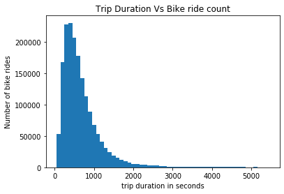

```python
# plot the histogram fro trip duration
bins = np.arange(50, 5500 , 100)
plt.hist(data=bike_data_clean , x= 'duration_sec' , bins= bins)
plt.xlabel('trip duration in seconds')
plt.ylabel('Number of bike rides')
plt.title('Trip Duration Vs Bike ride count');
```

```python
new_data = bike_data_clean.query("user_type=='Subscriber'")
```

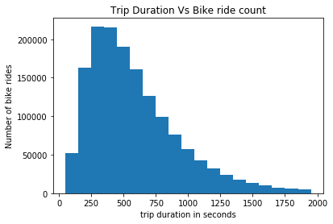

```python
bins = np.arange(50, 2000 , 100)
plt.hist(data=new_data , x= 'duration_sec' , bins= bins)
plt.xlabel('trip duration in seconds')
plt.ylabel('Number of bike rides')
plt.title('Trip Duration Vs Bike ride count');
```

```python
new_data1 = bike_data_clean.query("user_type=='Customer'")
```

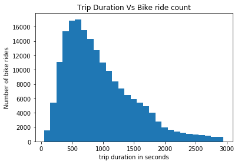

```python
bins = np.arange(50, 3000 , 100)
plt.hist(data=new_data1 , x= 'duration_sec' , bins= bins)
plt.xlabel('trip duration in seconds')
plt.ylabel('Number of bike rides')
plt.title('Trip Duration Vs Bike ride count');
```

### 2. Bike rides count across months

```python
bike_data_clean['start_time_month'] = bike_data_clean['start_time'].dt.month.astype(int)
```

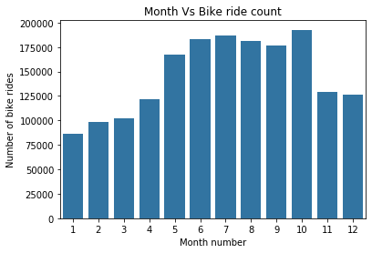

```python
color = sb.color_palette()[0]
order = bike_data_clean['start_time_month'].value_counts().index
sb.countplot(data=bike_data_clean , x= 'start_time_month', color=color )
plt.xlabel('Month number')
plt.ylabel('Number of bike rides')
plt.title('Month Vs Bike ride count');
```

### Observations:

- We can see a gradual increase in bike rides over the months from the starting of the year. It reached maximum value in October and dropped suddenly in Novembner and December
- This sudden drop could be because of the Holiday season. (people may go out of San Francisco during holidays / not go to office)

### 3. Bike rides count across weekdays

```python
bike_data_clean['start_time_day'] = bike_data_clean['start_time'].dt.day.astype(int)
```

```python
bike_data_clean['start_time_day_name'] = bike_data_clean['start_time'].dt.day_name()
```

```python
bike_data_clean['start_time_day_name'].value_counts()
```

```
Tuesday      304289
Wednesday    301735
Thursday     299013
Monday       280124
Friday       274083
Saturday     155217
Sunday       136073
Name: start_time_day_name, dtype: int64
```

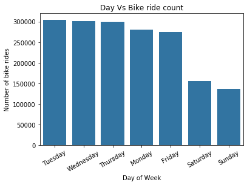

```python
color = sb.color_palette()[0]
order = bike_data_clean['start_time_day_name'].value_counts().index
sb.countplot(data=bike_data_clean , x= 'start_time_day_name', color=color , order=order)
plt.xlabel('Day of Week')
plt.ylabel('Number of bike rides')
plt.title('Day Vs Bike ride count')
plt.xticks(rotation = 30);
```

### Observation:

The sudden drop in number of bike rides on weekends clearly shows that people tend to use these bikes mostly while going ofr work(during weekdays)

### 4. Bike ride usage by types of users

```python
user_type_counts = bike_data_clean['user_type'].value_counts()
user_type_counts.shape[0]
```

```
2
```

```python
total_count = bike_data_clean.shape[0]
total_count
```

```
1750534
```

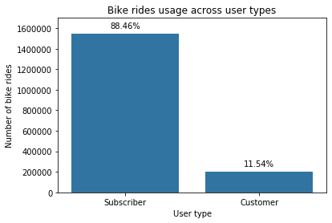

```python
#order = bike_data_clean['start_time_day_name'].value_counts().index
sb.countplot(data=bike_data_clean , x= 'user_type', color=color)
plt.xlabel('User type')
plt.ylabel('Number of bike rides')
plt.title('Bike rides usage across user types')
plt.ylim(0,1700000)
for i in range(user_type_counts.shape[0]):
    count = user_type_counts[i]
    pct_string = '{:0.2f}%'.format(100*count/total_count)
    plt.text(i , count+50000, pct_string , ha= 'center')
```

### Observation

- Out of total bike rides, ~89% of bike rides are done by subscribers and only ~11% of rides are done by customers.
- The plot clearly shows that subscribers make use of this program a lot more than usual customers

### Bike usage across Genders

```python
gender_type_counts = bike_data_clean['member_gender'].value_counts()
gender_type_counts.shape[0]
```

```
3
```

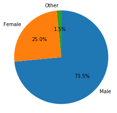

```python
plt.pie(gender_type_counts , labels= gender_type_counts.index , startangle=90 , counterclock=False , autopct='%.1f%%')
plt.axis('Square');
```

### Observation:

Male users contribute more to the bike ride usage as comapred to female and other users over the year.

### Of the features you investigated, were there any unusual distributions? Did you perform any operations on the data to tidy, adjust, or change the form of the data? If so, why did you do this?

- I observed that birty year details for some mebers were going back till 1800. Hence, to keep a crisp and clear dataset, I have considered users whoe are 80 and below.

## Bivariate Exploration

1. To start off with,I am plotting a boxplot of gender Vs age

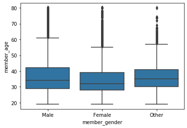

```python
color = sb.color_palette()[0]
sb.boxplot(data = bike_data_clean , x='member_gender' , y = 'member_age' , color=color)
```

```python
bike_data_clean.query("member_gender =='Female' and member_age>55").shape
```

```
(20821, 20)
```

```python
bike_data_clean.query("member_gender =='Male' and member_age>60").shape
```

```
(35266, 20)
```

```python
bike_data_clean.query("member_gender =='Other' and member_age>55").shape
```

```
(1171, 20)
```

### 2. Gender Vs bike_share_for_all_trip

```python
bike_data_clean
```

|  | duration_sec | start_time | end_time | start_station_id | start_station_name | start_station_latitude | start_station_longitude | end_station_id | end_station_name | end_station_latitude | end_station_longitude | bike_id | user_type | member_birth_year | member_gender | bike_share_for_all_trip | member_age | start_time_month | start_time_day | start_time_day_name |
| --- | --- | --- | --- | --- | --- | --- | --- | --- | --- | --- | --- | --- | --- | --- | --- | --- | --- | --- | --- | --- |
| 0 | 75284 | 2018-01-31 22:52:35.239 | 2018-02-01 19:47:19.824 | 120.0 | Mission Dolores Park | 37.761420 | -122.426435 | 285.0 | Webster St at O'Farrell St | 37.783521 | -122.431158 | 2765 | Subscriber | 1986 | Male | No | 33 | 1 | 31 | Wednesday |
| 1 | 71576 | 2018-01-31 14:23:55.889 | 2018-02-01 10:16:52.116 | 304.0 | Jackson St at 5th St | 37.348759 | -121.894798 | 296.0 | 5th St at Virginia St | 37.325998 | -121.877120 | 3039 | Customer | 1996 | Male | No | 23 | 1 | 31 | Wednesday |
| 2 | 39966 | 2018-01-31 19:52:24.667 | 2018-02-01 06:58:31.053 | 74.0 | Laguna St at Hayes St | 37.776435 | -122.426244 | 19.0 | Post St at Kearny St | 37.788975 | -122.403452 | 617 | Subscriber | 1991 | Male | No | 28 | 1 | 31 | Wednesday |
| 3 | 453 | 2018-01-31 23:53:53.632 | 2018-02-01 00:01:26.805 | 110.0 | 17th & Folsom Street Park (17th St at Folsom St) | 37.763708 | -122.415204 | 134.0 | Valencia St at 24th St | 37.752428 | -122.420628 | 3571 | Subscriber | 1988 | Male | No | 31 | 1 | 31 | Wednesday |
| 4 | 180 | 2018-01-31 23:52:09.903 | 2018-01-31 23:55:10.807 | 81.0 | Berry St at 4th St | 37.775880 | -122.393170 | 93.0 | 4th St at Mission Bay Blvd S | 37.770407 | -122.391198 | 1403 | Subscriber | 1980 | Male | No | 39 | 1 | 31 | Wednesday |
| 5 | 996 | 2018-01-31 23:34:56.004 | 2018-01-31 23:51:32.674 | 134.0 | Valencia St at 24th St | 37.752428 | -122.420628 | 4.0 | Cyril Magnin St at Ellis St | 37.785881 | -122.408915 | 3675 | Subscriber | 1987 | Male | Yes | 32 | 1 | 31 | Wednesday |
| 6 | 825 | 2018-01-31 23:34:14.027 | 2018-01-31 23:47:59.809 | 305.0 | Ryland Park | 37.342725 | -121.895617 | 317.0 | San Salvador St at 9th St | 37.333955 | -121.877349 | 1453 | Subscriber | 1994 | Female | Yes | 25 | 1 | 31 | Wednesday |
| 7 | 432 | 2018-01-31 23:34:26.484 | 2018-01-31 23:41:39.297 | 89.0 | Division St at Potrero Ave | 37.769218 | -122.407646 | 43.0 | San Francisco Public Library (Grove St at Hyde... | 37.778768 | -122.415929 | 2928 | Subscriber | 1993 | Male | No | 26 | 1 | 31 | Wednesday |
| 8 | 601 | 2018-01-31 23:29:46.832 | 2018-01-31 23:39:48.000 | 223.0 | 16th St Mission BART Station 2 | 37.764765 | -122.420091 | 86.0 | Market St at Dolores St | 37.769305 | -122.426826 | 3016 | Subscriber | 1957 | Male | No | 62 | 1 | 31 | Wednesday |
| 9 | 887 | 2018-01-31 23:24:16.357 | 2018-01-31 23:39:04.123 | 308.0 | San Pedro Square | 37.336802 | -121.894090 | 297.0 | Locust St at Grant St | 37.322980 | -121.887931 | 55 | Subscriber | 1976 | Female | Yes | 43 | 1 | 31 | Wednesday |
| 10 | 210 | 2018-01-31 23:33:03.046 | 2018-01-31 23:36:33.704 | 7.0 | Frank H Ogawa Plaza | 37.804562 | -122.271738 | 186.0 | Lakeside Dr at 14th St | 37.801319 | -122.262642 | 2602 | Subscriber | 1976 | Male | No | 43 | 1 | 31 | Wednesday |
| 11 | 188 | 2018-01-31 23:30:58.136 | 2018-01-31 23:34:06.391 | 98.0 | Valencia St at 16th St | 37.765052 | -122.421866 | 76.0 | McCoppin St at Valencia St | 37.771662 | -122.422423 | 2556 | Subscriber | 1964 | Female | No | 55 | 1 | 31 | Wednesday |
| 12 | 808 | 2018-01-31 23:19:58.603 | 2018-01-31 23:33:27.531 | 67.0 | San Francisco Caltrain Station 2 (Townsend St... | 37.776639 | -122.395526 | 98.0 | Valencia St at 16th St | 37.765052 | -122.421866 | 3041 | Subscriber | 1976 | Male | Yes | 43 | 1 | 31 | Wednesday |
| 13 | 378 | 2018-01-31 23:23:23.068 | 2018-01-31 23:29:42.044 | 80.0 | Townsend St at 5th St | 37.775306 | -122.397380 | 78.0 | Folsom St at 9th St | 37.773717 | -122.411647 | 546 | Subscriber | 1995 | Female | No | 24 | 1 | 31 | Wednesday |
| 14 | 686 | 2018-01-31 23:07:15.313 | 2018-01-31 23:18:41.558 | 312.0 | San Jose Diridon Station | 37.329732 | -121.901782 | 317.0 | San Salvador St at 9th St | 37.333955 | -121.877349 | 1886 | Subscriber | 1997 | Female | No | 22 | 1 | 31 | Wednesday |
| 15 | 450 | 2018-01-31 23:07:13.063 | 2018-01-31 23:14:43.814 | 241.0 | Ashby BART Station | 37.852477 | -122.270213 | 157.0 | 65th St at Hollis St | 37.846784 | -122.291376 | 3583 | Subscriber | 1994 | Male | No | 25 | 1 | 31 | Wednesday |
| 16 | 294 | 2018-01-31 23:08:12.000 | 2018-01-31 23:13:06.636 | 239.0 | Bancroft Way at Telegraph Ave | 37.868813 | -122.258764 | 244.0 | Shattuck Ave at Hearst Ave | 37.873792 | -122.268618 | 2144 | Subscriber | 1983 | Male | No | 36 | 1 | 31 | Wednesday |
| 17 | 150 | 2018-01-31 23:10:09.586 | 2018-01-31 23:12:40.333 | 182.0 | 19th Street BART Station | 37.809013 | -122.268247 | 183.0 | Telegraph Ave at 19th St | 37.808702 | -122.269927 | 3468 | Subscriber | 1945 | Male | Yes | 74 | 1 | 31 | Wednesday |
| 18 | 462 | 2018-01-31 23:03:48.940 | 2018-01-31 23:11:31.029 | 119.0 | 18th St at Noe St | 37.761047 | -122.432642 | 134.0 | Valencia St at 24th St | 37.752428 | -122.420628 | 1432 | Subscriber | 1971 | Male | Yes | 48 | 1 | 31 | Wednesday |
| 19 | 379 | 2018-01-31 23:04:27.701 | 2018-01-31 23:10:46.976 | 176.0 | MacArthur BART Station | 37.828410 | -122.266315 | 189.0 | Genoa St at 55th St | 37.839649 | -122.271756 | 997 | Subscriber | 1975 | Male | No | 44 | 1 | 31 | Wednesday |
| 20 | 880 | 2018-01-31 22:53:41.302 | 2018-01-31 23:08:21.443 | 123.0 | Folsom St at 19th St | 37.760594 | -122.414817 | 145.0 | 29th St at Church St | 37.743684 | -122.426806 | 3725 | Subscriber | 1986 | Male | No | 33 | 1 | 31 | Wednesday |
| 21 | 1210 | 2018-01-31 22:45:37.125 | 2018-01-31 23:05:47.576 | 285.0 | Webster St at O'Farrell St | 37.783521 | -122.431158 | 133.0 | Valencia St at 22nd St | 37.755213 | -122.420975 | 1059 | Subscriber | 1991 | Male | No | 28 | 1 | 31 | Wednesday |
| 22 | 259 | 2018-01-31 23:01:12.792 | 2018-01-31 23:05:32.157 | 239.0 | Bancroft Way at Telegraph Ave | 37.868813 | -122.258764 | 266.0 | Parker St at Fulton St | 37.862464 | -122.264791 | 1208 | Subscriber | 1994 | Male | No | 25 | 1 | 31 | Wednesday |
| 23 | 592 | 2018-01-31 22:53:27.779 | 2018-01-31 23:03:20.290 | 202.0 | Washington St at 8th St | 37.800754 | -122.274894 | 195.0 | Bay Pl at Vernon St | 37.812314 | -122.260779 | 1834 | Customer | 1978 | Male | No | 41 | 1 | 31 | Wednesday |
| 24 | 1059 | 2018-01-31 22:45:16.570 | 2018-01-31 23:02:56.285 | 141.0 | Valencia St at Cesar Chavez St | 37.747998 | -122.420219 | 79.0 | 7th St at Brannan St | 37.773492 | -122.403673 | 1248 | Subscriber | 1988 | Male | No | 31 | 1 | 31 | Wednesday |
| 25 | 375 | 2018-01-31 22:56:31.082 | 2018-01-31 23:02:46.583 | 15.0 | San Francisco Ferry Building (Harry Bridges Pl... | 37.795392 | -122.394203 | 6.0 | The Embarcadero at Sansome St | 37.804770 | -122.403234 | 3401 | Subscriber | 1988 | Male | No | 31 | 1 | 31 | Wednesday |
| 26 | 300 | 2018-01-31 22:57:24.042 | 2018-01-31 23:02:24.272 | 114.0 | Rhode Island St at 17th St | 37.764478 | -122.402570 | 93.0 | 4th St at Mission Bay Blvd S | 37.770407 | -122.391198 | 3224 | Subscriber | 1981 | Male | No | 38 | 1 | 31 | Wednesday |
| 27 | 2219 | 2018-01-31 22:24:39.943 | 2018-01-31 23:01:39.571 | 30.0 | San Francisco Caltrain (Townsend St at 4th St) | 37.776598 | -122.395282 | 81.0 | Berry St at 4th St | 37.775880 | -122.393170 | 1757 | Subscriber | 1991 | Female | No | 28 | 1 | 31 | Wednesday |
| 28 | 330 | 2018-01-31 22:55:48.073 | 2018-01-31 23:01:18.506 | 99.0 | Folsom St at 15th St | 37.767037 | -122.415443 | 124.0 | 19th St at Florida St | 37.760447 | -122.410807 | 3379 | Subscriber | 1983 | Male | No | 36 | 1 | 31 | Wednesday |
| 29 | 870 | 2018-01-31 22:45:38.235 | 2018-01-31 23:00:09.034 | 285.0 | Webster St at O'Farrell St | 37.783521 | -122.431158 | 106.0 | Sanchez St at 17th St | 37.763242 | -122.430675 | 1503 | Customer | 1990 | Female | No | 29 | 1 | 31 | Wednesday |
| ... | ... | ... | ... | ... | ... | ... | ... | ... | ... | ... | ... | ... | ... | ... | ... | ... | ... | ... | ... | ... |
| 1750504 | 331 | 2018-12-01 00:48:27.529 | 2018-12-01 00:53:59.495 | 70.0 | Central Ave at Fell St | 37.773311 | -122.444293 | 39.0 | Scott St at Golden Gate Ave | 37.778999 | -122.436861 | 968 | Subscriber | 1994 | Male | No | 25 | 12 | 1 | Saturday |
| 1750505 | 310 | 2018-12-01 00:45:44.868 | 2018-12-01 00:50:55.797 | 252.0 | Channing Way at Shattuck Ave | 37.865847 | -122.267443 | 238.0 | MLK Jr Way at University Ave | 37.871719 | -122.273068 | 367 | Subscriber | 1991 | Male | No | 28 | 12 | 1 | Saturday |
| 1750506 | 1338 | 2018-12-01 00:27:24.875 | 2018-12-01 00:49:43.349 | 371.0 | Lombard St at Columbus Ave | 37.802746 | -122.413579 | 104.0 | 4th St at 16th St | 37.767045 | -122.390833 | 1985 | Subscriber | 1986 | Male | No | 33 | 12 | 1 | Saturday |
| 1750507 | 154 | 2018-12-01 00:44:24.838 | 2018-12-01 00:46:59.335 | 70.0 | Central Ave at Fell St | 37.773311 | -122.444293 | 52.0 | McAllister St at Baker St | 37.777416 | -122.441838 | 449 | Subscriber | 1994 | Male | No | 25 | 12 | 1 | Saturday |
| 1750508 | 862 | 2018-12-01 00:32:11.063 | 2018-12-01 00:46:33.790 | 4.0 | Cyril Magnin St at Ellis St | 37.785881 | -122.408915 | 86.0 | Market St at Dolores St | 37.769305 | -122.426826 | 4408 | Customer | 1975 | Male | No | 44 | 12 | 1 | Saturday |
| 1750509 | 1310 | 2018-12-01 00:23:53.342 | 2018-12-01 00:45:43.588 | 85.0 | Church St at Duboce Ave | 37.770083 | -122.429156 | 13.0 | Commercial St at Montgomery St | 37.794231 | -122.402923 | 1525 | Subscriber | 1994 | Male | Yes | 25 | 12 | 1 | Saturday |
| 1750510 | 230 | 2018-12-01 00:41:31.955 | 2018-12-01 00:45:22.416 | 312.0 | San Jose Diridon Station | 37.329732 | -121.901782 | 314.0 | Santa Clara St at Almaden Blvd | 37.333988 | -121.894902 | 1379 | Subscriber | 1957 | Male | No | 62 | 12 | 1 | Saturday |
| 1750511 | 2071 | 2018-12-01 00:09:55.580 | 2018-12-01 00:44:26.629 | 36.0 | Folsom St at 3rd St | 37.783830 | -122.398870 | 97.0 | 14th St at Mission St | 37.768265 | -122.420110 | 316 | Customer | 1991 | Male | No | 28 | 12 | 1 | Saturday |
| 1750512 | 1958 | 2018-12-01 00:11:35.022 | 2018-12-01 00:44:13.632 | 44.0 | Civic Center/UN Plaza BART Station (Market St ... | 37.781074 | -122.411738 | 5.0 | Powell St BART Station (Market St at 5th St) | 37.783899 | -122.408445 | 4395 | Subscriber | 1993 | Male | No | 26 | 12 | 1 | Saturday |
| 1750513 | 268 | 2018-12-01 00:37:23.134 | 2018-12-01 00:41:51.967 | 147.0 | 29th St at Tiffany Ave | 37.744067 | -122.421472 | 121.0 | Mission Playground | 37.759210 | -122.421339 | 4451 | Subscriber | 1989 | Male | No | 30 | 12 | 1 | Saturday |
| 1750514 | 1679 | 2018-12-01 00:13:35.143 | 2018-12-01 00:41:34.860 | 240.0 | Haste St at Telegraph Ave | 37.866043 | -122.258804 | 245.0 | Downtown Berkeley BART | 37.870139 | -122.268422 | 3701 | Customer | 1998 | Female | No | 21 | 12 | 1 | Saturday |
| 1750515 | 1658 | 2018-12-01 00:13:33.124 | 2018-12-01 00:41:11.763 | 240.0 | Haste St at Telegraph Ave | 37.866043 | -122.258804 | 245.0 | Downtown Berkeley BART | 37.870139 | -122.268422 | 3625 | Customer | 1998 | Female | No | 21 | 12 | 1 | Saturday |
| 1750516 | 293 | 2018-12-01 00:36:01.525 | 2018-12-01 00:40:55.285 | 95.0 | Sanchez St at 15th St | 37.766219 | -122.431060 | 72.0 | Page St at Scott St | 37.772406 | -122.435650 | 1043 | Subscriber | 1981 | Male | No | 38 | 12 | 1 | Saturday |
| 1750517 | 426 | 2018-12-01 00:32:13.125 | 2018-12-01 00:39:19.871 | 50.0 | 2nd St at Townsend St | 37.780526 | -122.390288 | 21.0 | Montgomery St BART Station (Market St at 2nd St) | 37.789625 | -122.400811 | 3154 | Subscriber | 1986 | Male | No | 33 | 12 | 1 | Saturday |
| 1750518 | 447 | 2018-12-01 00:31:36.148 | 2018-12-01 00:39:03.391 | 368.0 | Myrtle St at Polk St | 37.785434 | -122.419622 | 17.0 | Embarcadero BART Station (Beale St at Market St) | 37.792251 | -122.397086 | 1677 | Subscriber | 1980 | Other | Yes | 39 | 12 | 1 | Saturday |
| 1750519 | 1694 | 2018-12-01 00:09:17.159 | 2018-12-01 00:37:31.240 | 14.0 | Clay St at Battery St | 37.795001 | -122.399970 | 147.0 | 29th St at Tiffany Ave | 37.744067 | -122.421472 | 209 | Subscriber | 1993 | Male | No | 26 | 12 | 1 | Saturday |
| 1750520 | 269 | 2018-12-01 00:31:00.091 | 2018-12-01 00:35:29.871 | 98.0 | Valencia St at 16th St | 37.765052 | -122.421866 | 121.0 | Mission Playground | 37.759210 | -122.421339 | 3147 | Subscriber | 1993 | Male | No | 26 | 12 | 1 | Saturday |
| 1750521 | 685 | 2018-12-01 00:21:16.240 | 2018-12-01 00:32:42.000 | 109.0 | 17th St at Valencia St | 37.763316 | -122.421904 | 60.0 | 8th St at Ringold St | 37.774520 | -122.409449 | 3247 | Subscriber | 1987 | Female | No | 32 | 12 | 1 | Saturday |
| 1750522 | 681 | 2018-12-01 00:19:41.383 | 2018-12-01 00:31:02.605 | 15.0 | San Francisco Ferry Building (Harry Bridges Pl... | 37.795392 | -122.394203 | 323.0 | Broadway at Kearny | 37.798014 | -122.405950 | 3460 | Subscriber | 1959 | Male | No | 60 | 12 | 1 | Saturday |
| 1750523 | 1166 | 2018-12-01 00:11:04.864 | 2018-12-01 00:30:31.348 | 160.0 | West Oakland BART Station | 37.805318 | -122.294837 | 155.0 | Emeryville Public Market | 37.840521 | -122.293528 | 1579 | Subscriber | 1997 | Male | No | 22 | 12 | 1 | Saturday |
| 1750524 | 763 | 2018-12-01 00:17:34.497 | 2018-12-01 00:30:18.107 | 73.0 | Pierce St at Haight St | 37.771793 | -122.433708 | 121.0 | Mission Playground | 37.759210 | -122.421339 | 90 | Subscriber | 1991 | Female | No | 28 | 12 | 1 | Saturday |
| 1750525 | 760 | 2018-12-01 00:17:29.960 | 2018-12-01 00:30:10.178 | 73.0 | Pierce St at Haight St | 37.771793 | -122.433708 | 121.0 | Mission Playground | 37.759210 | -122.421339 | 2758 | Subscriber | 1991 | Male | No | 28 | 12 | 1 | Saturday |
| 1750526 | 538 | 2018-12-01 00:16:34.085 | 2018-12-01 00:25:32.455 | 5.0 | Powell St BART Station (Market St at 5th St) | 37.783899 | -122.408445 | 39.0 | Scott St at Golden Gate Ave | 37.778999 | -122.436861 | 4384 | Subscriber | 1991 | Male | No | 28 | 12 | 1 | Saturday |
| 1750527 | 671 | 2018-12-01 00:12:49.640 | 2018-12-01 00:24:01.512 | 34.0 | Father Alfred E Boeddeker Park | 37.783988 | -122.412408 | 92.0 | Mission Bay Kids Park | 37.772301 | -122.393028 | 4377 | Subscriber | 1972 | Male | Yes | 47 | 12 | 1 | Saturday |
| 1750528 | 498 | 2018-12-01 00:14:41.725 | 2018-12-01 00:23:00.408 | 7.0 | Frank H Ogawa Plaza | 37.804562 | -122.271738 | 214.0 | Market St at Brockhurst St | 37.823321 | -122.275732 | 2236 | Subscriber | 1992 | Male | No | 27 | 12 | 1 | Saturday |
| 1750529 | 1137 | 2018-12-01 00:01:49.693 | 2018-12-01 00:20:47.519 | 73.0 | Pierce St at Haight St | 37.771793 | -122.433708 | 50.0 | 2nd St at Townsend St | 37.780526 | -122.390288 | 273 | Subscriber | 1990 | Male | No | 29 | 12 | 1 | Saturday |
| 1750530 | 473 | 2018-12-01 00:11:54.811 | 2018-12-01 00:19:48.547 | 345.0 | Hubbell St at 16th St | 37.766474 | -122.398295 | 81.0 | Berry St at 4th St | 37.775880 | -122.393170 | 3035 | Subscriber | 1982 | Female | No | 37 | 12 | 1 | Saturday |
| 1750531 | 841 | 2018-12-01 00:02:48.726 | 2018-12-01 00:16:49.766 | 10.0 | Washington St at Kearny St | 37.795393 | -122.404770 | 58.0 | Market St at 10th St | 37.776619 | -122.417385 | 2034 | Subscriber | 1999 | Female | No | 20 | 12 | 1 | Saturday |
| 1750532 | 260 | 2018-12-01 00:05:27.615 | 2018-12-01 00:09:47.956 | 245.0 | Downtown Berkeley BART | 37.870139 | -122.268422 | 255.0 | Virginia St at Shattuck Ave | 37.876573 | -122.269528 | 2243 | Subscriber | 1991 | Male | No | 28 | 12 | 1 | Saturday |
| 1750533 | 292 | 2018-12-01 00:03:06.549 | 2018-12-01 00:07:59.080 | 93.0 | 4th St at Mission Bay Blvd S | 37.770407 | -122.391198 | 126.0 | Esprit Park | 37.761634 | -122.390648 | 545 | Subscriber | 1963 | Male | No | 56 | 12 | 1 | Saturday |

1750534 rows × 20 columns

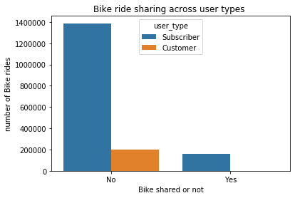

```python
sb.countplot(data = bike_data_clean , hue= 'user_type', x='bike_share_for_all_trip')
plt.xlabel('Bike shared or not')
plt.ylabel('number of Bike rides')
plt.title('Bike ride sharing across user types ');
```

```python
(bike_data_clean.query("bike_share_for_all_trip =='No' and user_type =='Customer'").shape[0])/(bike_data_clean.query("bike_share_for_all_trip =='No'").shape[0])
```

```
0.1271499219811748
```

### Observations:

From the above clustered graph, we can easilty see that usual customers have not shared a bike ride at all.

### 3. User types Vs across member age and count of bike rides

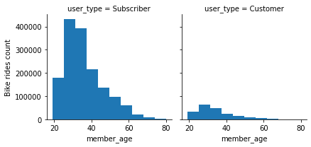

```python
g = sb.FacetGrid(data=bike_data_clean , col='user_type')
g.map(plt.hist ,'member_age')

g.set_axis_labels("member_age", "Bike rides count");
```

### 4. User type Vs trip duration and count of bike rides

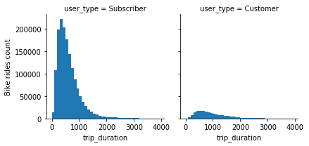

```python
bins = np.arange(0,4000,100)
g = sb.FacetGrid(data=bike_data_clean , col='user_type')
g.map(plt.hist ,'duration_sec' ,bins = bins )


g.set_axis_labels("trip_duration", "Bike rides count");
```

### Talk about some of the relationships you observed in this part of the investigation. How did the feature(s) of interest vary with other features in the dataset?

- There are a lot of outliers users across gender and Age. Irrespective of a gender, bike user's mean age is in the range of 30-35 years.
- Usual customers have not shared a bike ride at all and they contribute upto 12% of total users who have not shared a ride

## Multivariate Exploration

### 1. Performance comparison between customers and subscribers across genders over all months

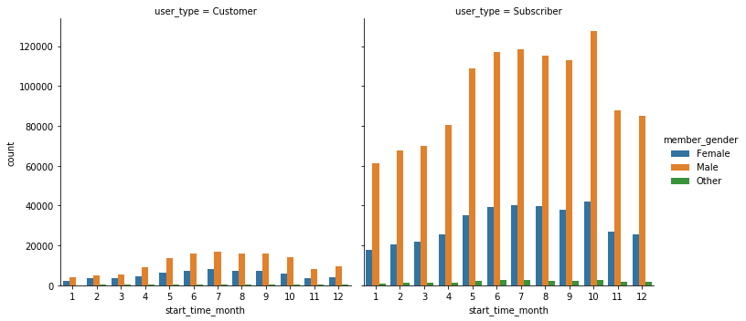

```python
sb.catplot(data=bike_data_clean, x='start_time_month', col="user_type", hue="member_gender", kind='count')
```

### 2. Performance comparison between customers and subscribers across genders over days of the week

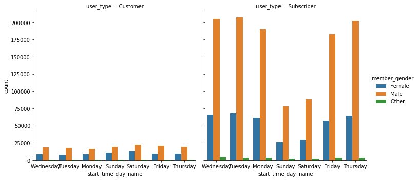

```python
sb.catplot(data=bike_data_clean, x='start_time_day_name', col="user_type", hue="member_gender", kind='count')
```

### Talk about some of the relationships you observed in this part of the investigation. Were there features that strengthened each other in terms of looking at your feature(s) of interest?

- Subsribers have used most of their rides in the month of October. Also, bike usage trend is quite comparable across months June, July , August and September( higher than the remaining months) . That means most subscribers prefer to ride bikes in summer
- For customers , maximum usage of buikes is also in months June, July , August and September which states that usual customers ( say they are visiting) like to ride bikes in summer.

### Were there any interesting or surprising interactions between features?

- Bike ride usage by usual customers is quite similar over days of the week. where interestingly, subscribers show maximum usage on weekdays as compared to weekends